# Скоринг по Автозаймам-финал_верс

```python
import pycaret
from pycaret.classification import *

import pandas as pd
from sklearn.metrics import confusion_matrix
import My_funk as my

import sqlalchemy
from scipy.stats import linregress

import matplotlib.pyplot as plt
#from upgradeds.rgfs import MyXGBRegressor
import math

import scipy.stats as stats
from scipy.stats import norm

import scipy.special as sps
from scipy.stats import kurtosis
from scipy.stats import skew
from scipy import stats
import statsmodels.api as sm
from scipy import *


##################################
import numpy as np
import mglearn
# from IPython.display import display
# plt.rc('font', family='Verdana')
from sklearn.model_selection import train_test_split
from sklearn.metrics import mean_squared_error, r2_score, roc_auc_score

from sklearn.model_selection import GridSearchCV

import matplotlib.pyplot as plt
from xgboost import XGBRegressor
from catboost import CatBoostRegressor, CatBoostClassifier, Pool
from catboost import *
import pyodbc
from collections import Counter
from functools import reduce
import seaborn as sns
import warnings
warnings.simplefilter(action='ignore', category=FutureWarning)

# from pylab import rcParams
# rcParams['figure.figsize'] = (9, 6)

%matplotlib inline
plt.rcParams["figure.figsize"] = (10.0, 7.0)
warnings.filterwarnings("ignore")

import os
import time
import datetime
```

```python
engine = sqlalchemy.create_engine("mssql+pyodbc://ads.otlnal.ru/dds?driver=ODBC+Driver+17+for+SQL+Server",
                                  fast_executemany=True)

db_name = "D:\Ponomarev\МодлеьАвтозаймы\ScoringCredAuto"
# pd.read_sql(' SELECT *   FROM [dds].[dbo].[ScoringCredAuto]', engine).to_pickle(db_name)
# # to_csv(db_name, index=False)

df = pd.read_pickle(db_name)

'''
print(df.select_dtypes(include = ['float64', 'int64']).columns)
print(df.select_dtypes(include = ['object']).columns)
'''

pd.set_option('display.max_columns', 100) #отображение всех колон
pd.set_option('display.max_rows', 100) #отображение всех строк
df.sort_values('Дата открытия по договору', inplace=True)
df.head()
```

|  | CreditAutoID | AutoID | PersonID | CreditID | Марка, модель | Бренд | Модель | Год выпуска | Одобренная сумма | Дата возврата. План | Установка GPS | Срок действия ПТС на дату одобрения в мес. | Срок действия ПТС 1 и меннее мес. | Срок действия ПТС 15 и меннее дней | Срок действия ПТС 1 день и менее | Наличие данных о серии и номере СТС | Наличие страховки | Разтаможка | Наличие VIN | Наличие номера кузова | Цвет кузова | Тип Цвета | MadeInRussia | BCategory | DCategory | Дата регистрации ПТС | Срок действия ПТС на дату одобрения в мес. по послед. влад. | Срок действия ПТС 1 и меннее мес. по послед. влад. | Срок действия ПТС 15 и меннее дней по послед. влад. | … |
| --- | --- | --- | --- | --- | --- | --- | --- | --- | --- | --- | --- | --- | --- | --- | --- | --- | --- | --- | --- | --- | --- | --- | --- | --- | --- | --- | --- | --- | --- | --- |
| 3 | 15 | 544 | 531699 | 1903799 | AUDI A8 | None | None | 1999 | 209600.0 | 2017-04-04 | 1 | 60 | 0 | 0 | 0 | 1 | 1 | 1 | 1 | 1 | ЧЕРНЫЙ | ЧЕРНЫЙ | None | None | None | None | 0 | 1 | 1 | … |
| 87 | 16 | 547 | 533135 | 1908336 | БМВ525IA | None | None | 2002 | 301200.0 | 2020-12-09 | 1 | 81 | 0 | 0 | 0 | 1 | 1 | 0 | 1 | 1 | СЕРЫЙ | СВЕТЛЫЙ | None | False | False | 2013-12-07 | 81 | 0 | 0 | … |
| 9 | 18 | 549 | 534184 | 1911740 | МАЗДА КАПЕЛЛА | None | None | 1999 | 118400.0 | 2016-10-09 | 1 | 1 | 1 | 0 | 0 | 1 | 1 | 0 | 0 | 1 | СЕРЫЙ | СВЕТЛЫЙ | None | None | None | None | 0 | 1 | 1 | … |
| 6 | 17 | 548 | 533864 | 1911432 | BMW X5 | None | None | 2007 | 896000.0 | 2018-07-28 | 1 | 61 | 0 | 0 | 0 | 1 | 1 | 0 | 1 | 1 | ЧЕРНЫЙ | ЧЕРНЫЙ | None | None | None | None | 0 | 1 | 1 | … |
| 30 | 19 | 550 | 534414 | 1912400 | INFINITI EX25 | None | None | 2011 | 1056000.0 | 2017-06-24 | 1 | 108 | 0 | 0 | 0 | 1 | 1 | 1 | 1 | 1 | ТЕМНО-БОРДОВЫЙ | ЦВЕТНОЙ | None | False | False | 2013-11-23 | 82 | 0 | 0 | … |

5 rows × 223 columns

```python
df.info()
```

```
<class 'pandas.core.frame.DataFrame'>
Int64Index: 1658 entries, 3 to 1624
Columns: 223 entries, CreditAutoID to Кол-во дней от выдачи
dtypes: datetime64[ns](3), float64(103), int64(67), object(50)
memory usage: 2.8+ MB
```

```python
df.shape
```

```
(1658, 223)
```

```python
df.columns.to_list()
```

```
['CreditAutoID',
 'AutoID',
 'PersonID',
 'CreditID',
 'Марка, модель',
 'Бренд',
 'Модель',
 'Год выпуска',
 'Одобренная сумма',
 'Дата возврата. План',
 'Установка GPS',
 'Срок действия ПТС на дату одобрения в мес.',
 'Срок действия ПТС 1 и меннее мес.',
 'Срок действия ПТС 15 и меннее дней',
 'Срок действия ПТС 1 день и менее',
 'Наличие данных о серии и номере СТС',
 'Наличие страховки',
 'Разтаможка',
 'Наличие VIN',
 'Наличие номера кузова',
 'Цвет кузова',
 'Тип Цвета',
 'MadeInRussia',
 'BCategory',
 'DCategory',
 'Дата регистрации ПТС',
 'Срок действия ПТС на дату одобрения в мес. по послед. влад.',
 'Срок действия ПТС 1 и меннее мес. по послед. влад.',
 'Срок действия ПТС 15 и меннее дней по послед. влад.',
 'Срок действия ПТС 1 день и менее по послед. влад.',
 'Кол-во владельцев',
 'Дубликат ПТС',
 'Регион ПТС по послед. владельцу',
 'IDРегиона',
 'УкрупнениеIDРегиона',
 'is_informative',
 'Расходы на услуги связи по абонентскому номеру',
 'Расходы на услуги связи по абонентскому номеруID',
 'Размер максимального платежа)',
 'Размер максимального платежа)ID',
```

[output cut: 168 more lines]

```
 'eqf_all_Сумма остатков открытых договоров',
 'eqf_all_Сумма остатков договоров на просрочке',
 'eqf_all_Сумма остатков договоров на просрочке до 120 дней',
 'eqf_all_Сумма остатков договоров на просрочке от 120 до 300 дней',
 'eqf_all_Сумма остатков договоров на просрочке более 300 дней',
 'eqf_all_Полная стоимость займа (кредита) в соответствии с договором займа (кредита)',
 'eqf_all_Размер периодического платежа (аннуитет)',
 'eqf_all_Сумма договора поручительства',
 'eqf_all_Сумма банковской гарантии',
 'Доля оплаты в ОД',
 'Доля  eqf_all_Сумма открытых договоров в выдаче',
 'Доля выданной сумма от оценочной стоимости',
 'Год выдачи',
 'Месяц выдачи',
 'Кол-во дней от выдачи']
```

```python
df_info = my.df_full(df.copy())
df_info.head()
```

|  | index | Count | Type | Type_dit | uniq_count | N_Per | uniq_Per | moda_top3 | numric |
| --- | --- | --- | --- | --- | --- | --- | --- | --- | --- |
| 0 | CreditAutoID | 1658 | int64 | i | 1658 | 100.0% | 100.000% | [1661, 1116, 1096] | 1 |
| 1 | AutoID | 1658 | int64 | i | 1057 | 100.0% | 63.752% | [664, 905, 724] | 1 |
| 2 | PersonID | 1658 | int64 | i | 938 | 100.0% | 56.574% | [575599, 560779, 634609] | 1 |
| 3 | CreditID | 1658 | int64 | i | 1658 | 100.0% | 100.000% | [3168253, 3872058, 2084125] | 1 |
| 4 | Марка, модель | 1658 | object | O | 580 | 100.0% | 34.982% | [TOYOTA COROLLA, TOYOTA CAMRY, PORSCHE CAYENNE] | 0 |

```python
my.df_full(df, color_='#B39DDB')
```

|  | index | Count | Type | Type_dit | uniq_count | N_Per | uniq_Per | moda_top3 | numric |
| --- | --- | --- | --- | --- | --- | --- | --- | --- | --- |
| 0 | CreditAutoID | 1658 | int64 | i | 1658 | 100.0% | 100.000% | [1661, 1116, 1096] | 1 |
| 1 | AutoID | 1658 | int64 | i | 1057 | 100.0% | 63.752% | [664, 905, 724] | 1 |
| 2 | PersonID | 1658 | int64 | i | 938 | 100.0% | 56.574% | [575599, 560779, 634609] | 1 |
| 3 | CreditID | 1658 | int64 | i | 1658 | 100.0% | 100.000% | [3168253, 3872058, 2084125] | 1 |
| 4 | Марка, модель | 1658 | object | O | 580 | 100.0% | 34.982% | ['TOYOTA COROLLA', 'TOYOTA CAMRY', 'PORSCHE CAYENNE'] | 0 |
| 5 | Бренд | 508 | object | O | 38 | 30.6% | 7.480% | ['TOYOTA', 'NISSAN', 'SUBARU'] | 0 |
| 6 | Модель | 508 | object | O | 183 | 30.6% | 36.024% | ['CAYENNE', 'CAMRY', 'COROLLA'] | 0 |
| 7 | Год выпуска | 1658 | object | O | 30 | 100.0% | 1.809% | ['2000', '2001', '2008'] | 1 |
| 8 | Одобренная сумма | 1658 | float64 | f | 638 | 100.0% | 38.480% | [248000.0, 420000.0, 200000.0] | 1 |
| 9 | Дата возврата. План | 1658 | object | O | 897 | 100.0% | 54.101% | [datetime.date(2020, 11, 11), datetime.date(2020, 11, 29), datetime.date(2020, 11, 12)] | 0 |
| 10 | Установка GPS | 1658 | int64 | i | 2 | 100.0% | 0.121% | [1, 0] | 1 |
| 11 | Срок действия ПТС на дату одобрения в мес. | 1658 | int64 | i | 216 | 100.0% | 13.028% | [85, 157, 48] | 1 |
| 12 | Срок действия ПТС 1 и меннее мес. | 1658 | int64 | i | 2 | 100.0% | 0.121% | [0, 1] | 1 |
| 13 | Срок действия ПТС 15 и меннее дней | 1658 | int64 | i | 2 | 100.0% | 0.121% | [0, 1] | 1 |
| 14 | Срок действия ПТС 1 день и менее | 1658 | int64 | i | 2 | 100.0% | 0.121% | [0, 1] | 1 |
| 15 | Наличие данных о серии и номере СТС | 1658 | int64 | i | 1 | 100.0% | 0.060% | [1] | 1 |
| 16 | Наличие страховки | 1658 | int64 | i | 2 | 100.0% | 0.121% | [0, 1] | 1 |
| 17 | Разтаможка | 1658 | int64 | i | 2 | 100.0% | 0.121% | [0, 1] | 1 |
| 18 | Наличие VIN | 1658 | int64 | i | 2 | 100.0% | 0.121% | [1, 0] | 1 |
| 19 | Наличие номера кузова | 1658 | int64 | i | 2 | 100.0% | 0.121% | [1, 0] | 1 |
| 20 | Цвет кузова | 1658 | object | O | 134 | 100.0% | 8.082% | ['ЧЕРНЫЙ', 'СЕРЫЙ', 'БЕЛЫЙ'] | 0 |
| 21 | Тип Цвета | 1658 | object | O | 3 | 100.0% | 0.181% | ['СВЕТЛЫЙ', 'ЦВЕТНОЙ', 'ЧЕРНЫЙ'] | 0 |
| 22 | MadeInRussia | 300 | object | O | 2 | 18.1% | 0.667% | [False, True] | 1 |
| 23 | BCategory | 1642 | object | O | 2 | 99.0% | 0.122% | [False, True] | 1 |
| 24 | DCategory | 1642 | object | O | 2 | 99.0% | 0.122% | [False, True] | 1 |
| 25 | Дата регистрации ПТС | 1637 | object | O | 770 | 98.7% | 47.037% | [datetime.date(2017, 3, 28), datetime.date(2016, 8, 23), datetime.date(2016, 11, 11)] | 0 |
| 26 | Срок действия ПТС на дату одобрения в мес. по послед. влад. | 1658 | int64 | i | 138 | 100.0% | 8.323% | [46, 42, 45] | 1 |
| 27 | Срок действия ПТС 1 и меннее мес. по послед. влад. | 1658 | int64 | i | 2 | 100.0% | 0.121% | [0, 1] | 1 |
| 28 | Срок действия ПТС 15 и меннее дней по послед. влад. | 1658 | int64 | i | 2 | 100.0% | 0.121% | [0, 1] | 1 |
| 29 | Срок действия ПТС 1 день и менее по послед. влад. | 1658 | int64 | i | 2 | 100.0% | 0.121% | [0, 1] | 1 |

[output cut: 193 more lines]

```python
df['Дата открытия по договору'] = df['Дата открытия по договору'].apply(pd.to_datetime)
```

```python
pd.DataFrame(data=[ i[0] for i in df['Марка, модель'].str.split(" ")], columns=['Name'] ).Name.value_counts()
```

```
TOYOTA                      224
NISSAN                      139
ТОЙОТА                      105
HONDA                        88
SUBARU                       85
                           ...
МITSUBISHI                    1
BMB                           1
РЕНО                          1
toyota                        1
ФОЛЬКСВАГЕНПАССАТВАРИАНТ      1
Name: Name, Length: 151, dtype: int64
```

```python
# rus_auto = ['LADA',  'ВАЗ', 'ГАЗ', 'ЛАДА', 'ЖИГУ', 'НИВА', 'УАЗ']

# df['Отечественый бренд'] = df['Марка, модель'].map(lambda x: 1 if any([i.lower() in x for i in rus_auto]) else 0)
```

```python
# eu_auto = ['СИТРОЕ', 'СЕТРО', 'CITRO', 'ЯГУАР', 'YGUAR', 'Мерс', 'Mers', 'MERC', 'BMW', 'BMB', 'БМВ',
#             'Ауди', 'AUDI', 'Peuge', 'infini', 'инфин', 'субару', 'SUBARU', 'СЕТРОЕН', 'porsh', 'порш', 'каен']

# df['Европейский бренд'] = df['Марка, модель'].map(lambda x: 1 if any([i.lower() in x for i in eu_auto]) else 0)

# df['Европейский бренд'].value_counts()
```

```python
# df['Азиатский бренд'] = 1 - df[['Европейский бренд', 'Отечественый бренд']].sum(axis=1)
# df['Азиатский бренд'].value_counts()
```

```python
# def id_brend(df):
#     if df['Отечественый бренд'] == 1:
#         return 1
#     if  df['Европейский бренд'] == 1:
#         return 2
#     return 3

# df['Принадлженость бренда'] = df.apply(id_brend, axis=1)
# df['Принадлженость бренда'].value_counts(dropna=True)
```

```python
df['Группа по сумме выдачи'] = pd.cut( df['Сумма выдачи'], bins= [0, 100000, 200000, 300000, 500000], right=False)
df['Группа по сумме выдачи'].value_counts()
```

```
[0, 100000)         744
[100000, 200000)    445
[300000, 500000)    212
[200000, 300000)    184
Name: Группа по сумме выдачи, dtype: int64
```

```python
df['Группа доли выдачи в стоимости'] = pd.cut( df['Доля выданной сумма от оценочной стоимости'], bins= [0, .2, .40, .60, .80, 1], right=False)
df['Группа доли выдачи в стоимости'].value_counts()
```

```
[0.4, 0.6)    509
[0.2, 0.4)    436
[0.6, 0.8)    290
[0.0, 0.2)    271
[0.8, 1.0)    116
Name: Группа доли выдачи в стоимости, dtype: int64
```

```python
categorical = [
'Регион ПТС по послед. владельцу',
#  'meg_HOME_REGION',
#  'meg_HOME_DISTRICT',
#  'meg_HOME_CITY',
#  'meg_HOME_LOCALITY',
#  'meg_HOME_STREET',
#  'meg_WORK_REGION',
#  'meg_WORK_DISTRICT',
#  'meg_WORK_CITY',
#  'meg_WORK_LOCALITY',
#  'meg_WORK_STREET',
#  'meg_DISB_REGION',
#  'meg_DISB_CITY',
#  'meg_DISB_STREET',
#  'meg_top1_region',
 'Пол',
 'ВозрастнаяКатегория',
 'Жилье клиента',
#  'Адрес регистрации',
#  'Адрес фактический',
 'Категория профессии',
 'Группа по сумме выдачи',
# -'Группа доли выдачи в стоимости'

#  'Форма собственности',
#  'Названии компании',
#  'Адрес работы',
#  'Socr',
#  'Факт адрес Регион',
#  'Socr1',
#  'Факт адрес Город/Село'
]

my.df_full(df[categorical], color_ = '#FFEA00')
```

|  | index | Count | Type | Type_dit | uniq_count | N_Per | uniq_Per | moda_top3 | numric |
| --- | --- | --- | --- | --- | --- | --- | --- | --- | --- |
| 0 | Регион ПТС по послед. владельцу | 1637 | object | O | 18 | 98.7% | 1.100% | ['1AC46B49-3209-4814-B7BF-A509EA1AECD9', '393AECCB-89EF-4A7E-AE42-08D5CEBC2E30', '8276C6A1-1A86-4F0D-8920-ABA34D4CC34A'] | 0 |
| 1 | Пол | 1658 | object | O | 2 | 100.0% | 0.121% | ['М', 'Ж'] | 0 |
| 2 | ВозрастнаяКатегория | 1658 | object | O | 6 | 100.0% | 0.362% | ['ЗрелыйВозраст', 'СредняяВзрослость', 'РанняяВзрослость'] | 0 |
| 3 | Жилье клиента | 1658 | object | O | 3 | 100.0% | 0.181% | ['Собств', 'Родст', 'Съем'] | 0 |
| 4 | Категория профессии | 1650 | object | O | 14 | 99.5% | 0.848% | ['СОТРУДНИКИ КОММЕРЧЕСКИХ СТРУКТУР', 'РУКОВОДИТЕЛИ ВЫСШЕГО ЗВЕНА', 'РАБОЧИЙ ПЕРСОНАЛ'] | 0 |
| 5 | Группа по сумме выдачи | 1585 | category | O | 4 | 95.6% | 0.252% | [Interval(0, 100000, closed='left'), Interval(100000, 200000, closed='left'), Interval(300000, 500000, closed='left')] | 0 |

```python
df[categorical] = df[categorical].astype(str)
```

```python
features = [
'Год выпуска',
'Одобренная сумма',
'Срок действия ПТС на дату одобрения в мес.',
'Срок действия ПТС 1 и меннее мес.',
'Срок действия ПТС 15 и меннее дней',
'Срок действия ПТС 1 день и менее',
'Наличие данных о серии и номере СТС',
'Разтаможка',
'Наличие VIN',
'Наличие номера кузова',
'MadeInRussia',
'BCategory',
'DCategory',
'Срок действия ПТС на дату одобрения в мес. по послед. влад.',
'Срок действия ПТС 1 и меннее мес. по послед. влад.',
'Срок действия ПТС 15 и меннее дней по послед. влад.',
'Срок действия ПТС 1 день и менее по послед. влад.',
'Кол-во владельцев',
'Дубликат ПТС',
'is_informative',
'Расходы на услуги связи по абонентскому номеруID',
'Размер максимального платежа)ID',
'Круг общения (количество абонентских номеров, с которыми у абонентского номера были транзакции)ID',
'Количество блокировок абонентского номераID',
'Длительность блокировок абонентского номераID',
'Срок жизни абонентского номераID',
'Желаемая сумма',
'Возраст',
'Количество детей',
'MaritalStatusID',
'Кол-во номеров по "Номера родственников"',
'Кол-во номеров по "При регистрации"',
'Кол-во номеров по "Рабочий телефон"',
'Кол-во номеров по "Знакомые"',
'Кол-во номеров по "Номера заемщика"',
'Всего заведено номеров',
'Адрес фактический наспункт',
'Стаж работы',
'Доход',
'Смена имени',
'На ежедвение',
'Образование',
'Инвалидность',
'Проживает в Новосибирске',
'Возраст прописки в годах',
'Займ по счету АЗ',
'Займ по счету в тч ОН',
'Повторный клиент АЗ',
'Повторный клиент в тч ОН',
'Сумма открытых займов на момент обращения',
'Процент гашения выданных займов на момент обращения АЗ',
'Доля дохода в незакрытых займах на момент обращения',
'Доля дохода в сумме выдачи',
'Доля выданной сумма от желаемой',
'Срок пассивности клиеинта на момент обращения',
'eqf_all_Тип недееспособности',
'eqf_all_Кол-во партнеров по принадлежности при запросе',
'eqf_all_Количество субъектов по данному договору',
'eqf_all_Сумма обязательств по договору',
'eqf_all_Сумма первоначального предельного лимита по договору',
'eqf_all_Доля последней оплаты в ОД',
'eqf_all_Сумма погашенного основного долга по договору субъектом КИ',
'eqf_all_Доля ппогашенного основного долга',
'eqf_all_Доля гашений к основному долгу',
'eqf_all_Текущая задолженность',
'eqf_all_Кол–во закрытых просрочек – менее 6 дней',
'eqf_all_Кол–во закрытых просрочек – от 6 до 30 дней',
'eqf_all_Кол–во закрытых просрочек – от 31 до 60 дней',
'eqf_all_Кол–во закрытых просрочек – от 61 до 90 дней',
'eqf_all_Кол–во закрытых просрочек – более 90 дней',
'eqf_all_Текущая просроченная задолженность, сумма',
'eqf_all_Средняя просроченная задолженность, дней',
'eqf_all_Ср. максимальная сумма просроченной задолженности',
'eqf_all_Ср. количество пролонгаций',
'eqf_all_Кл-во отметок о погашении за счет обеспечения',
'eqf_all_Кол-во закрытых договоров(гашение)',
'eqf_all_Доля закрытых договоров(гашение)',
'eqf_all_Кол-во договоров безнадежных(банкрот)',
'eqf_all_Кол-во договоров переданных коллекторам',
'eqf_all_Кол-во открытых договоров',
'eqf_all_Кол-во договоров на просрочке',
'eqf_all_Кол-во договоров на просрочке до 120 дней',
'eqf_all_Кол-во договоров на просрочке от 120 до 300 дней',
'eqf_all_Кол-во договоров на просрочке более 300 дней',
'eqf_all_Сумма закрытых договоров(гашение)',
'eqf_all_Доля суммы закрытых договоров(гашение)',
'eqf_all_Сумма договоров безнадежных(банкрот)',
'eqf_all_Сумма договоров переданных коллекторам',
'eqf_all_Сумма открытых договоров',
'eqf_all_Сумма договоров на просрочке',
'eqf_all_Сумма договоров на просрочке до 120 дней',
'eqf_all_Сумма договоров на просрочке от 120 до 300 дней',
'eqf_all_Сумма договоров на просрочке более 300 дней',
'eqf_all_Сумма остатков договоров безнадежных(банкрот)',
'eqf_all_Сумма остатков договоров переданных коллекторам',
'eqf_all_Сумма остатков открытых договоров',
'eqf_all_Сумма остатков договоров на просрочке',
'eqf_all_Сумма остатков договоров на просрочке до 120 дней',
'eqf_all_Сумма остатков договоров на просрочке от 120 до 300 дней',
'eqf_all_Сумма остатков договоров на просрочке более 300 дней',
'eqf_all_Размер периодического платежа (аннуитет)',
'Доля  eqf_all_Сумма открытых договоров в выдаче',
'Доля выданной сумма от оценочной стоимости',
'Кол-во дней от выдачи'
]

df[features] = df[features].astype(float)

my.df_full(df[features], color_='#B2FF59')
```

|  | index | Count | Type | Type_dit | uniq_count | N_Per | uniq_Per | moda_top3 | numric |
| --- | --- | --- | --- | --- | --- | --- | --- | --- | --- |
| 0 | Год выпуска | 1658 | float64 | f | 30 | 100.0% | 1.809% | [2000.0, 2001.0, 2008.0] | 1 |
| 1 | Одобренная сумма | 1658 | float64 | f | 638 | 100.0% | 38.480% | [248000.0, 420000.0, 200000.0] | 1 |
| 2 | Срок действия ПТС на дату одобрения в мес. | 1658 | float64 | f | 216 | 100.0% | 13.028% | [85.0, 157.0, 48.0] | 1 |
| 3 | Срок действия ПТС 1 и меннее мес. | 1658 | float64 | f | 2 | 100.0% | 0.121% | [0.0, 1.0] | 1 |
| 4 | Срок действия ПТС 15 и меннее дней | 1658 | float64 | f | 2 | 100.0% | 0.121% | [0.0, 1.0] | 1 |
| 5 | Срок действия ПТС 1 день и менее | 1658 | float64 | f | 2 | 100.0% | 0.121% | [0.0, 1.0] | 1 |
| 6 | Наличие данных о серии и номере СТС | 1658 | float64 | f | 1 | 100.0% | 0.060% | [1.0] | 1 |
| 7 | Разтаможка | 1658 | float64 | f | 2 | 100.0% | 0.121% | [0.0, 1.0] | 1 |
| 8 | Наличие VIN | 1658 | float64 | f | 2 | 100.0% | 0.121% | [1.0, 0.0] | 1 |
| 9 | Наличие номера кузова | 1658 | float64 | f | 2 | 100.0% | 0.121% | [1.0, 0.0] | 1 |
| 10 | MadeInRussia | 300 | float64 | f | 2 | 18.1% | 0.667% | [0.0, 1.0] | 1 |
| 11 | BCategory | 1642 | float64 | f | 2 | 99.0% | 0.122% | [0.0, 1.0] | 1 |
| 12 | DCategory | 1642 | float64 | f | 2 | 99.0% | 0.122% | [0.0, 1.0] | 1 |
| 13 | Срок действия ПТС на дату одобрения в мес. по послед. влад. | 1658 | float64 | f | 138 | 100.0% | 8.323% | [46.0, 42.0, 45.0] | 1 |
| 14 | Срок действия ПТС 1 и меннее мес. по послед. влад. | 1658 | float64 | f | 2 | 100.0% | 0.121% | [0.0, 1.0] | 1 |
| 15 | Срок действия ПТС 15 и меннее дней по послед. влад. | 1658 | float64 | f | 2 | 100.0% | 0.121% | [0.0, 1.0] | 1 |
| 16 | Срок действия ПТС 1 день и менее по послед. влад. | 1658 | float64 | f | 2 | 100.0% | 0.121% | [0.0, 1.0] | 1 |
| 17 | Кол-во владельцев | 1637 | float64 | f | 7 | 98.7% | 0.428% | [3.0, 5.0, 1.0] | 1 |
| 18 | Дубликат ПТС | 1637 | float64 | f | 2 | 98.7% | 0.122% | [0.0, 1.0] | 1 |
| 19 | is_informative | 1298 | float64 | f | 2 | 78.3% | 0.154% | [0.0, 1.0] | 1 |
| 20 | Расходы на услуги связи по абонентскому номеруID | 1298 | float64 | f | 6 | 78.3% | 0.462% | [3.0, 2.0, 0.0] | 1 |
| 21 | Размер максимального платежа)ID | 1298 | float64 | f | 6 | 78.3% | 0.462% | [3.0, 4.0, 0.0] | 1 |
| 22 | Круг общения (количество абонентских номеров, с которыми у абонентского номера были транзакции)ID | 1298 | float64 | f | 6 | 78.3% | 0.462% | [5.0, 0.0, 4.0] | 1 |
| 23 | Количество блокировок абонентского номераID | 1298 | float64 | f | 6 | 78.3% | 0.462% | [0.0, 2.0, 1.0] | 1 |
| 24 | Длительность блокировок абонентского номераID | 1298 | float64 | f | 6 | 78.3% | 0.462% | [0.0, 1.0, 4.0] | 1 |
| 25 | Срок жизни абонентского номераID | 1298 | float64 | f | 6 | 78.3% | 0.462% | [5.0, 4.0, 0.0] | 1 |
| 26 | Желаемая сумма | 1658 | float64 | f | 151 | 100.0% | 9.107% | [0.0, 100000.0, 50000.0] | 1 |
| 27 | Возраст | 1658 | float64 | f | 54 | 100.0% | 3.257% | [37.0, 33.0, 32.0] | 1 |
| 28 | Количество детей | 1658 | float64 | f | 8 | 100.0% | 0.483% | [0.0, 1.0, 2.0] | 1 |
| 29 | MaritalStatusID | 1643 | float64 | f | 5 | 99.1% | 0.304% | [3.0, 1.0, 4.0] | 1 |

[output cut: 74 more lines]

```python
result_tab = categorical + features
df[result_tab].head()
```

|  | Регион ПТС по послед. владельцу | Пол | ВозрастнаяКатегория | Жилье клиента | Категория профессии | Группа по сумме выдачи | Год выпуска | Одобренная сумма | Срок действия ПТС на дату одобрения в мес. | Срок действия ПТС 1 и меннее мес. | Срок действия ПТС 15 и меннее дней | Срок действия ПТС 1 день и менее | Наличие данных о серии и номере СТС | Разтаможка | Наличие VIN | Наличие номера кузова | MadeInRussia | BCategory | DCategory | Срок действия ПТС на дату одобрения в мес. по послед. влад. | Срок действия ПТС 1 и меннее мес. по послед. влад. | Срок действия ПТС 15 и меннее дней по послед. влад. | Срок действия ПТС 1 день и менее по послед. влад. | Кол-во владельцев | Дубликат ПТС | is_informative | Расходы на услуги связи по абонентскому номеруID | Размер максимального платежа)ID | Круг общения (количество абонентских номеров, с которыми у абонентского номера были транзакции)ID | … |
| --- | --- | --- | --- | --- | --- | --- | --- | --- | --- | --- | --- | --- | --- | --- | --- | --- | --- | --- | --- | --- | --- | --- | --- | --- | --- | --- | --- | --- | --- | --- |
| 3 | None | Ж | ЗрелыйВозраст | Собств | ТОРГОВЫЙ ПЕРСОНАЛ | [100000.0, 200000.0) | 1999.0 | 209600.0 | 60.0 | 0.0 | 0.0 | 0.0 | 1.0 | 1.0 | 1.0 | 1.0 | NaN | NaN | NaN | 0.0 | 1.0 | 1.0 | 1.0 | NaN | NaN | NaN | NaN | NaN | NaN | … |
| 87 | 1AC46B49-3209-4814-B7BF-A509EA1AECD9 | М | ЗрелыйВозраст | Родст | ВОДИТЕЛИ | [100000.0, 200000.0) | 2002.0 | 301200.0 | 81.0 | 0.0 | 0.0 | 0.0 | 1.0 | 0.0 | 1.0 | 1.0 | NaN | 0.0 | 0.0 | 81.0 | 0.0 | 0.0 | 0.0 | 1.0 | 1.0 | NaN | NaN | NaN | NaN | … |
| 9 | None | М | ЗрелыйВозраст | Родст | СОТРУДНИКИ КОММЕРЧЕСКИХ СТРУКТУР | [0.0, 100000.0) | 1999.0 | 118400.0 | 1.0 | 1.0 | 0.0 | 0.0 | 1.0 | 0.0 | 0.0 | 1.0 | NaN | NaN | NaN | 0.0 | 1.0 | 1.0 | 1.0 | NaN | NaN | NaN | NaN | NaN | NaN | … |
| 6 | None | М | ПожилойВозраст | Собств | ВОДИТЕЛИ | [200000.0, 300000.0) | 2007.0 | 896000.0 | 61.0 | 0.0 | 0.0 | 0.0 | 1.0 | 0.0 | 1.0 | 1.0 | NaN | NaN | NaN | 0.0 | 1.0 | 1.0 | 1.0 | NaN | NaN | NaN | NaN | NaN | NaN | … |
| 30 | 1AC46B49-3209-4814-B7BF-A509EA1AECD9 | Ж | ЗрелыйВозраст | Родст | РУКОВОДИТЕЛИ СРЕДНЕГО ЗВЕНА | nan | 2011.0 | 1056000.0 | 108.0 | 0.0 | 0.0 | 0.0 | 1.0 | 1.0 | 1.0 | 1.0 | NaN | 0.0 | 0.0 | 82.0 | 0.0 | 0.0 | 0.0 | 4.0 | 0.0 | NaN | NaN | NaN | NaN | … |

5 rows × 110 columns

## Тестовая выборка

```python
# Выюорка для теста скоринга

test_month = ['2019-09', '2019-10', '2019-11', '2019-12', '2020-01']

df_learn = df[df['Месяц выдачи'].isin(test_month)].copy()
df_learn.head()
```

|  | CreditAutoID | AutoID | PersonID | CreditID | Марка, модель | Бренд | Модель | Год выпуска | Одобренная сумма | Дата возврата. План | Установка GPS | Срок действия ПТС на дату одобрения в мес. | Срок действия ПТС 1 и меннее мес. | Срок действия ПТС 15 и меннее дней | Срок действия ПТС 1 день и менее | Наличие данных о серии и номере СТС | Наличие страховки | Разтаможка | Наличие VIN | Наличие номера кузова | Цвет кузова | Тип Цвета | MadeInRussia | BCategory | DCategory | Дата регистрации ПТС | Срок действия ПТС на дату одобрения в мес. по послед. влад. | Срок действия ПТС 1 и меннее мес. по послед. влад. | Срок действия ПТС 15 и меннее дней по послед. влад. | … |
| --- | --- | --- | --- | --- | --- | --- | --- | --- | --- | --- | --- | --- | --- | --- | --- | --- | --- | --- | --- | --- | --- | --- | --- | --- | --- | --- | --- | --- | --- | --- |
| 1475 | 1385 | 1626 | 983003 | 3593360 | VOLVO XC90 | VOLVO | XC90 | 2007.0 | 400800.0 | 2019-12-19 | 0 | 161.0 | 0.0 | 0.0 | 0.0 | 1.0 | 0 | 1.0 | 1.0 | 1.0 | СЕРЕБРИСТЫЙ | ЦВЕТНОЙ | 0.0 | 1.0 | 0.0 | 2012-07-26 | 99.0 | 0.0 | 0.0 | … |
| 1298 | 1386 | 1627 | 983753 | 3595894 | PORSCHE CAYENNE | PORSCHE | CAYENNE | 2004.0 | 363750.0 | 2020-11-30 | 0 | 162.0 | 0.0 | 0.0 | 0.0 | 1.0 | 0 | 0.0 | 1.0 | 1.0 | ЧЕРНЫЙ | ЧЕРНЫЙ | 0.0 | 1.0 | 0.0 | 2019-09-05 | 12.0 | 0.0 | 0.0 | … |
| 1491 | 1387 | 1628 | 984553 | 3598601 | LEXUS GS450H | LEXUS | GS450H | 2008.0 | 482700.0 | 2019-11-14 | 0 | 149.0 | 0.0 | 0.0 | 0.0 | 1.0 | 0 | 1.0 | 1.0 | 1.0 | ТЕМНО-ГОЛУБОЙ | ЦВЕТНОЙ | 0.0 | 1.0 | 0.0 | 2019-09-07 | 12.0 | 0.0 | 0.0 | … |
| 1478 | 1388 | 1630 | 795925 | 3603157 | IRAN KHODRO SAMAND | IRAN KHODRO | SAMAND | 2006.0 | 59400.0 | 2020-09-26 | 0 | 165.0 | 0.0 | 0.0 | 0.0 | 1.0 | 0 | 1.0 | 1.0 | 1.0 | СИНИЙ | ЦВЕТНОЙ | 0.0 | 1.0 | 0.0 | 2019-09-10 | 12.0 | 0.0 | 0.0 | … |
| 1573 | 1389 | 984 | 634609 | 3607831 | SUBARU TRIBECA B9 | None | None | 2005.0 | 436000.0 | 2020-10-16 | 1 | 73.0 | 0.0 | 0.0 | 0.0 | 1.0 | 0 | 0.0 | 1.0 | 1.0 | СЕРЕБРИСТЫЙ | ЦВЕТНОЙ | NaN | 0.0 | 0.0 | 2017-08-10 | 37.0 | 0.0 | 0.0 | … |

5 rows × 225 columns

### Тренировочная выборка

```python
# исключаем данные
now = datetime.datetime.today()
month_ago = datetime.timedelta(days=30)
data_ago = pd.to_datetime( (now - month_ago).strftime('%x') )
print(now, data_ago)

df_tr =  df[ ( df['Дата открытия по договору'] <= data_ago ) &
           ~(df['Месяц выдачи'].isin(test_month ) )
          ].copy()

df_val = df_tr.copy().sample(n=300) # создаем дополнительную тестовую выборку
df_tr = df_tr.drop(index=df_val.index).reset_index(drop=True) # удаляем из трененровочной тест
```

```
2020-11-12 10:49:26.839292 2020-10-13 00:00:00
```

```python
# режем дтасеты для обучения в зависимости от целевой по платящим

slice_train9 = - ( len(df_tr) - len(df_tr[df_tr['Кол-во дней от выдачи'] > 9*30.5] ) )

df_train9 =  df_tr[:slice_train9].copy()
df_train9.shape
```

```
(1122, 225)
```

```python
max(df_train9['Дата открытия по договору']), min(df_train9['Дата открытия по договору'])
```

```
(Timestamp('2020-02-08 00:00:00'), Timestamp('2016-08-05 00:00:00'))
```

### Целевая

```python
len(df_train9[result_tab].columns.tolist())
```

```
110
```

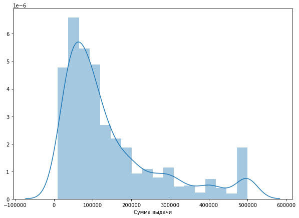

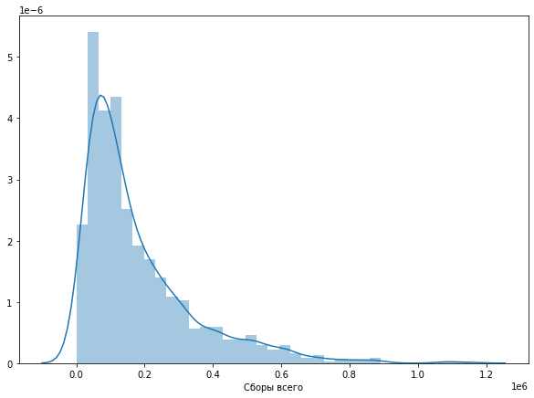

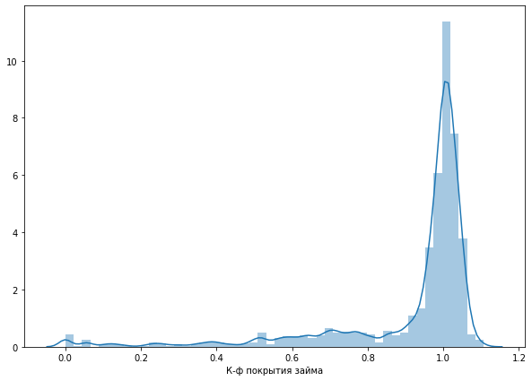

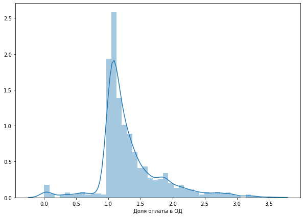

```python
for i in ['Сумма выдачи', 'Сборы всего', 'К-ф покрытия займа', 'Доля оплаты в ОД']:
    sns.distplot( df_train9[i])
    plt.show()
```

```python
final_target_bin = 'Платящий на 240 дне'
```

```python
df_train9[final_target_bin].value_counts()
```

```
1    1021
0     101
Name: Платящий на 240 дне, dtype: int64
```

```python
df.to_csv("D:\Ponomarev\МодлеьАвтозаймы\StatValidScoring.csv")
```

```python
# наклон: наклон линии регрессии

# перехват: перехват линии регрессии

# r-значение: коэффициент корреляции

# p-значение: двухстороннее p-значение для теста гипотезы, нулевой гипотезой которого является то, что наклон равен нулю

# stderr: стандартная ошибка оценки
rvalue = []
pvalue = []
stderr = []

factor = features

targ = final_target_bin
y = df_train9[targ].values
for l in factor:
    x = df_train9[l].fillna(-1)
    print(f'{l} \n, rvalue(correl)={ linregress(x, y)}')

    rvalue.append(eval(str(linregress(x, y)[2:3]))[0])
    pvalue.append(linregress(x, y)[3:4])
    stderr.append(linregress(x, y)[4:5])

corr = pd.DataFrame({'Name metric' : factor,
                    'Rvalue' : rvalue,
                    'Pvalue' : pvalue,
                    'Stderr' : stderr}
                   )

# расчет только коррелиации
# R_xy = np.corrcoef(x, y)
# R_xy[1][0]
```

```
Год выпуска
, rvalue(correl)=LinregressResult(slope=-0.003182425045348296, intercept=7.287269817812325, rvalue=-0.05833329349409569, pvalue=0.05076828160456471, stderr=0.0016273932567817397)
Одобренная сумма
, rvalue(correl)=LinregressResult(slope=-6.307894397704108e-08, intercept=0.9324401378299082, rvalue=-0.06286752643452037, pvalue=0.03524230333185062, stderr=2.992189485483208e-08)
Срок действия ПТС на дату одобрения в мес.
, rvalue(correl)=LinregressResult(slope=0.0008684078757008639, intercept=0.818664674860347, rvalue=0.15914971509502981, pvalue=8.360457063539935e-08, stderr=0.00016096741913951786)
Срок действия ПТС 1 и меннее мес.
, rvalue(correl)=LinregressResult(slope=nan, intercept=nan, rvalue=0.0, pvalue=1.0, stderr=inf)
Срок действия ПТС 15 и меннее дней
, rvalue(correl)=LinregressResult(slope=nan, intercept=nan, rvalue=0.0, pvalue=1.0, stderr=inf)
Срок действия ПТС 1 день и менее
, rvalue(correl)=LinregressResult(slope=nan, intercept=nan, rvalue=0.0, pvalue=1.0, stderr=inf)
Наличие данных о серии и номере СТС
, rvalue(correl)=LinregressResult(slope=nan, intercept=nan, rvalue=0.0, pvalue=1.0, stderr=inf)
Разтаможка
, rvalue(correl)=LinregressResult(slope=0.05548242257258029, intercept=0.8893617021276596, rvalue=0.09367947405368472, pvalue=0.001681851081806911, stderr=0.017619269531279114)
Наличие VIN
, rvalue(correl)=LinregressResult(slope=-0.042944182067862276, intercept=0.9352051835853131, rvalue=-0.07386929943861638, pvalue=0.01332474567425969, stderr=0.017323801450471413)
Наличие номера кузова
, rvalue(correl)=LinregressResult(slope=-0.028863432165319013, intercept=0.9345238095238096, rvalue=-0.0359834866425257, pvalue=0.22845083109693118, stderr=0.023952694284788672)
MadeInRussia
, rvalue(correl)=LinregressResult(slope=-0.021329861806529044, intercept=0.8896788837706123, rvalue=-0.016258702701357614, pvalue=0.5864175379513932, stderr=0.0391954568743228)
BCategory
, rvalue(correl)=LinregressResult(slope=0.0008582140114731444, intercept=0.9099477543400033, rvalue=0.0006887500925905832, pvalue=0.9816145012572539, stderr=0.037232724437370066)
DCategory
, rvalue(correl)=LinregressResult(slope=0.16113105924596047, intercept=0.9111310592459605, rvalue=0.047368899279327144, pvalue=0.11278401022055469, stderr=0.10152878114724387)
Срок действия ПТС на дату одобрения в мес. по послед. влад.
, rvalue(correl)=LinregressResult(slope=0.0020651771084687514, intercept=0.799611158527433, rvalue=0.20952931046235976, pvalue=1.3463182528499497e-12, stderr=0.000287974870322321)
Срок действия ПТС 1 и меннее мес. по послед. влад.
, rvalue(correl)=LinregressResult(slope=-0.16113105924596047, intercept=0.9111310592459605, rvalue=-0.047368899279327144, pvalue=0.11278401022055469, stderr=0.10152878114724387)
Срок действия ПТС 15 и меннее дней по послед. влад.
, rvalue(correl)=LinregressResult(slope=-0.16113105924596047, intercept=0.9111310592459605, rvalue=-0.047368899279327144, pvalue=0.11278401022055469, stderr=0.10152878114724387)
Срок действия ПТС 1 день и менее по послед. влад.
, rvalue(correl)=LinregressResult(slope=-0.16113105924596047, intercept=0.9111310592459605, rvalue=-0.047368899279327144, pvalue=0.11278401022055469, stderr=0.10152878114724387)
Кол-во владельцев
, rvalue(correl)=LinregressResult(slope=0.009000279341121312, intercept=0.8767405012570351, rvalue=0.05857265498005691, pvalue=0.049825083687179625, stderr=0.00458359046470996)
Дубликат ПТС
, rvalue(correl)=LinregressResult(slope=-0.06481025431567819, intercept=0.9257515146418719, rvalue=-0.10085667739805143, pvalue=0.0007164996022481587, stderr=0.01910336658833499)
is_informative
, rvalue(correl)=LinregressResult(slope=-0.20790796544142523, intercept=0.8771838592841958, rvalue=-0.3712660759807117, pvalue=5.429889878861372e-38, stderr=0.015537142975620016)
```

[output cut: 153 more lines]

```
, rvalue(correl)=LinregressResult(slope=-3.515809305498075e-07, intercept=0.9170697551126091, rvalue=-0.11143398335455121, pvalue=0.00018393535415327003, stderr=9.368829389890556e-08)
eqf_all_Сумма остатков договоров на просрочке до 120 дней
, rvalue(correl)=LinregressResult(slope=-1.1618740670251851e-07, intercept=0.9104039807565747, rvalue=-0.006551169697898743, pvalue=0.826496209337021, stderr=5.299341144286452e-07)
eqf_all_Сумма остатков договоров на просрочке от 120 до 300 дней
, rvalue(correl)=LinregressResult(slope=-3.633167918582489e-07, intercept=0.9159873242147547, rvalue=-0.11268450900953698, pvalue=0.0001553510534800467, stderr=9.572762744039049e-08)
eqf_all_Сумма остатков договоров на просрочке более 300 дней
, rvalue(correl)=LinregressResult(slope=0.08431372549019624, intercept=0.9176470588235295, rvalue=0.08468858825505617, pvalue=0.004529905043996398, stderr=0.02964157996852903)
eqf_all_Размер периодического платежа (аннуитет)
, rvalue(correl)=LinregressResult(slope=9.308059626209814e-06, intercept=0.9092944009218765, rvalue=0.016620956083455204, pvalue=0.5781029499917205, stderr=1.6731471838671527e-05)
Доля  eqf_all_Сумма открытых договоров в выдаче
, rvalue(correl)=LinregressResult(slope=0.0033350576206046135, intercept=0.8998254777278774, rvalue=0.08581105656590508, pvalue=0.004021716845777354, stderr=0.001157034191870648)
Доля выданной сумма от оценочной стоимости
, rvalue(correl)=LinregressResult(slope=-0.31023421349029384, intercept=1.0416706535414337, rvalue=-0.25491595485884405, pvalue=4.2129086781318735e-18, stderr=0.03516362290709879)
Кол-во дней от выдачи
, rvalue(correl)=LinregressResult(slope=0.0001832443981595561, intercept=0.7181937206553127, rvalue=0.19451595766790114, pvalue=4.992532618007062e-11, stderr=2.761155772603037e-05)
```

```python
corr.sort_values(by='Rvalue', ascending=False)
```

|  | Name metric | Rvalue | Pvalue | Stderr |
| --- | --- | --- | --- | --- |
| 13 | Срок действия ПТС на дату одобрения в мес. по ... | 0.209529 | (1.3463182528499497e-12,) | (0.000287974870322321,) |
| 103 | Кол-во дней от выдачи | 0.194516 | (4.992532618007062e-11,) | (2.761155772603037e-05,) |
| 2 | Срок действия ПТС на дату одобрения в мес. | 0.159150 | (8.360457063539935e-08,) | (0.00016096741913951786,) |
| 52 | Доля дохода в сумме выдачи | 0.129999 | (1.2527918521489222e-05,) | (0.014506228987194829,) |
| 76 | eqf_all_Доля закрытых договоров(гашение) | 0.119985 | (5.598547922899919e-05,) | (0.01614122265023445,) |
| ... | ... | ... | ... | ... |
| 24 | Длительность блокировок абонентского номераID | -0.120010 | (5.5780878558429e-05,) | (0.007695750185594142,) |
| 23 | Количество блокировок абонентского номераID | -0.139363 | (2.7886093470215633e-06,) | (0.008542040722286324,) |
| 26 | Желаемая сумма | -0.153788 | (2.2619746648794304e-07,) | (5.859762798888994e-08,) |
| 102 | Доля выданной сумма от оценочной стоимости | -0.254916 | (4.2129086781318735e-18,) | (0.03516362290709879,) |
| 19 | is_informative | -0.371266 | (5.429889878861372e-38,) | (0.015537142975620016,) |

104 rows × 4 columns

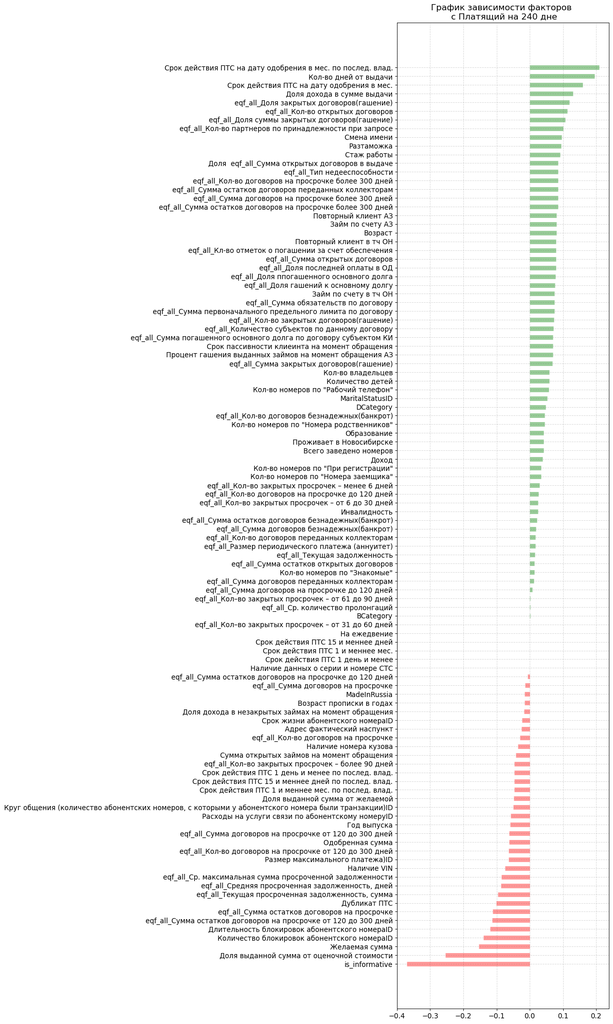

```python
target = final_target_bin
corr['colors'] = ['red' if x < 0 else 'green' for x in corr['Rvalue']]
corr.sort_values('Rvalue', inplace=True)


x = corr['Name metric']
y = corr['Rvalue']


plt.figure(figsize=(15,25), dpi= 80)
graf = plt.hlines(y= x, xmin=0, xmax= y, color=corr.colors, alpha=0.4, linewidth=8)


plt.title(f'График зависимости факторов \n с {target}', fontdict={'size':15})
plt.grid(linestyle='--', alpha=0.5)
plt.tick_params( labelsize=12)

plt.tight_layout()


plt.show()
# df_correl.sort_values(by='R_value', ascending=False)
```

```python
stat_an = ['Группа по сумме выдачи', 'Группа доли выдачи в стоимости',
        'Пол', 'ВозрастнаяКатегория', 'Категория профессии', 'Жилье клиента']
for i in stat_an:
    res = df_train9.groupby(str(i)).agg({ final_target_bin : ['mean', 'count']}).reset_index()\
        .sort_values(by=( final_target_bin,'mean'))
    print(res)
```

```
  Группа по сумме выдачи Платящий на 240 дне
                                        mean count
4                    nan            0.686275    51
3   [300000.0, 500000.0)            0.783784   111
2   [200000.0, 300000.0)            0.888889   117
1   [100000.0, 200000.0)            0.938511   309
0        [0.0, 100000.0)            0.945693   534
  Группа доли выдачи в стоимости Платящий на 240 дне
                                                mean count
3                     [0.6, 0.8)            0.745562   169
4                     [0.8, 1.0)            0.771429    35
2                     [0.4, 0.6)            0.913158   380
1                     [0.2, 0.4)            0.966154   325
0                     [0.0, 0.2)            0.975369   203
  Пол Платящий на 240 дне
```

[output cut: 33 more lines]

# Установка параметров для обучения

```python
x, y = df_train9[result_tab], df_train9[final_target_bin]
```

```python
categorical_cols = np.where(x.columns.isin(categorical))[0]
```

```python
categorical_cols
```

```
array([0, 1, 2, 3, 4, 5], dtype=int64)
```

```python
len(y)
```

```
1122
```

**Тренировочная модель**

```python
#'Платящий на 240 дне'
x_train, x_test, y_train, y_test = train_test_split(x, y, test_size=0.3, random_state=50)
print(f'Train size: {x_train.shape}')
Silent=False
```

**Подбор наилучших параметров**

```python
clf = CatBoostClassifier( cat_features=categorical_cols, eval_metric='AUC', silent=Silent)
```

```python
## Тестируем при минимальных параметрах

param_grid = {
    'n_estimators' : [1000],
    'learning_rate' : [ 0.008, 0.01, 0.05],
    'max_depth' : [2, 5, 8, 10, 12 ]
}
```

```python
GS = GridSearchCV(clf, param_grid, scoring='roc_auc', cv=2, n_jobs=-1)
```

```python
GS.fit(x_train, y_train, eval_set=[(x_train, y_train), (x_test, y_test)])
my.score(GS , x_train, x_test, y_train, y_test)
```

```python
print(GS.best_score_)
print(GS.best_params_)

# 0.8473925860666848
# {'learning_rate': 0.01, 'max_depth': 10, 'n_estimators': 1000}
```

Подбор параметров вручную

```python
start_time = time.time()


clf_4 = CatBoostClassifier(n_estimators=1000, learning_rate=0.01, max_depth=2,
                           cat_features=categorical_cols, eval_metric='AUC',
                           silent=Silent).fit(x_train, y_train, eval_set=[(x_train, y_train), (x_test, y_test)])
my.score(clf_4 , x_train, x_test, y_train, y_test)


clf_5 = CatBoostClassifier(n_estimators=1000, learning_rate=0.01, max_depth=5,
                           cat_features=categorical_cols, eval_metric='AUC',
                           silent=Silent).fit(x_train, y_train, eval_set=[(x_train, y_train), (x_test, y_test)])
my.score(clf_5 , x_train, x_test, y_train, y_test)



clf_6 = CatBoostClassifier(n_estimators=1000, learning_rate=0.01, max_depth=8,
                           cat_features=categorical_cols, eval_metric='AUC',
                           silent=Silent).fit(x_train, y_train, eval_set=[(x_train, y_train), (x_test, y_test)])
my.score(clf_6 , x_train, x_test, y_train, y_test)


clf_7 = CatBoostClassifier(n_estimators=1000, learning_rate=0.015, max_depth=5,
                           cat_features=categorical_cols, eval_metric='AUC',
                           silent=Silent).fit(x_train, y_train, eval_set=[(x_train, y_train), (x_test, y_test)])
my.score(clf_7 , x_train, x_test, y_train, y_test)



clf_8 = CatBoostClassifier(n_estimators=1000, learning_rate=0.009, max_depth=5,
                           cat_features=categorical_cols, eval_metric='AUC',
                           silent=Silent).fit(x_train, y_train, eval_set=[(x_train, y_train), (x_test, y_test)])
my.score(clf_8 ,x_train, x_test, y_train, y_test)





print("\n----------------------------\n")

my.score(clf_4 , x_train, x_test, y_train, y_test)
my.score(clf_5 , x_train, x_test, y_train, y_test)
my.score(clf_6 , x_train, x_test, y_train, y_test)
my.score(clf_7 , x_train, x_test, y_train, y_test)
my.score(clf_8 , x_train, x_test, y_train, y_test)


print("\n----------------------------\n")


print(clf_4.best_iteration_, '|', clf_4.best_score_['validation_1']['AUC'] )
print(clf_5.best_iteration_, '|', clf_5.best_score_['validation_1']['AUC'] )
print(clf_6.best_iteration_, '|', clf_6.best_score_['validation_1']['AUC'] )
print(clf_7.best_iteration_, '|', clf_7.best_score_['validation_1']['AUC'] )
print(clf_8.best_iteration_, '|', clf_8.best_score_['validation_1']['AUC'] )


print("--- %s minuts ---" % ((time.time() - start_time) / 60))
```

```python
x_to_predict = df_val[result_tab]
Silent=False
```

**Обучаем модель для предсказания**

```python
# clf_res1 = CatBoostClassifier(n_estimators=1000, learning_rate=0.01, max_depth=3, cat_features=categorical_cols,
#                          eval_metric='AUC', silent=Silent).fit(x, y * 1, eval_set=[(x, y)])

# clf_res3 = CatBoostClassifier(n_estimators=1000, learning_rate=0.01, max_depth=5, cat_features=categorical_cols,
#                          eval_metric='AUC', silent=Silent).fit(x, y * 1, eval_set=[(x, y)])

clf_res9 = CatBoostClassifier(n_estimators=1000, learning_rate=0.01, max_depth=8, cat_features=categorical_cols,
                        eval_metric='AUC', silent=Silent).fit(x, y * 1, eval_set=[(x, y)])


# clf_res = CatBoostClassifier(n_estimators=1000, learning_rate=0.01, max_depth=10, cat_features=categorical_cols,
#                          eval_metric='AUC', silent=Silent).fit(x, y * 1, eval_set=[(x, y)])


# clf_res_d = CatBoostClassifier(n_estimators=1000, learning_rate=0.009, max_depth=5, cat_features=categorical_cols,
#                          eval_metric='AUC', silent=Silent).fit(x, y * 1, eval_set=[(x, y)])
```

[output not shown]

[output cut: 950 more lines]

[output not shown]

```python
df_val.drop(['ProbaPredict_1', 'ProbaPredict_3', 'ProbaPredict_9', 'ProbaPredict', 'ProbaPredict_d' ], errors='ignore')

# df_val['ProbaPredict_1'] = clf_res1.predict_proba(x_to_predict)[:, 1]
# df_val['ProbaPredict_3'] = clf_res3.predict_proba(x_to_predict)[:, 1]
df_val['ProbaPredict_9'] = clf_res9.predict_proba(x_to_predict)[:, 1]
# df_val['ProbaPredict'] = clf_res.predict_proba(x_to_predict)[:, 1]
# df_val['ProbaPredict_d'] = clf_res_d.predict_proba(x_to_predict)[:, 1]
```

```python
# importances_clf1 = pd.Series(clf_res1.feature_importances_, index=result_tab).rename('clf')  # влияние предикатов
# importances_clf1 = importances_clf1.sort_values(ascending=False)
# print(importances_clf1[:10])
```

```python
# importances_clf3 = pd.Series(clf_res3.feature_importances_, index=result_tab).rename('clf')  # влияние предикатов
# importances_clf3 = importances_clf3.sort_values(ascending=False)
# print(importances_clf3[:10])
```

```python
importances_clf9 = pd.Series(clf_res9.feature_importances_, index=result_tab).rename('clf')  # влияние предикатов
importances_clf9 = importances_clf9.sort_values(ascending=False)
print(importances_clf9[:10])
```

```
is_informative                                                 14.403423
Доля выданной сумма от оценочной стоимости                      3.901148
Доля выданной сумма от желаемой                                 3.268436
Срок действия ПТС на дату одобрения в мес. по послед. влад.     2.916603
Жилье клиента                                                   2.543170
Возраст прописки в годах                                        2.541955
Срок жизни абонентского номераID                                2.376653
Стаж работы                                                     2.137099
Доля дохода в сумме выдачи                                      1.947973
Желаемая сумма                                                  1.919642
Name: clf, dtype: float64
```

```python
# importances_clf_ = pd.Series(clf_res.feature_importances_, index=result_tab).rename('clf1')  # влияние предикатов
# importances_clf_ = importances_clf_.sort_values(ascending=False)
# print(importances_clf_[:10])
```

```python
# importances_clf_d = pd.Series(clf_res_d.feature_importances_, index=result_tab).rename('clf1')  # влияние предикатов
# importances_clf_d = importances_clf_d.sort_values(ascending=False)
# print(importances_clf_d[:10])
```

```python
list(df_val.columns)
```

```
['CreditAutoID',
 'AutoID',
 'PersonID',
 'CreditID',
 'Марка, модель',
 'Бренд',
 'Модель',
 'Год выпуска',
 'Одобренная сумма',
 'Дата возврата. План',
 'Установка GPS',
 'Срок действия ПТС на дату одобрения в мес.',
 'Срок действия ПТС 1 и меннее мес.',
 'Срок действия ПТС 15 и меннее дней',
 'Срок действия ПТС 1 день и менее',
 'Наличие данных о серии и номере СТС',
 'Наличие страховки',
 'Разтаможка',
 'Наличие VIN',
 'Наличие номера кузова',
 'Цвет кузова',
 'Тип Цвета',
 'MadeInRussia',
 'BCategory',
 'DCategory',
 'Дата регистрации ПТС',
 'Срок действия ПТС на дату одобрения в мес. по послед. влад.',
 'Срок действия ПТС 1 и меннее мес. по послед. влад.',
 'Срок действия ПТС 15 и меннее дней по послед. влад.',
 'Срок действия ПТС 1 день и менее по послед. влад.',
 'Кол-во владельцев',
 'Дубликат ПТС',
 'Регион ПТС по послед. владельцу',
 'IDРегиона',
 'УкрупнениеIDРегиона',
 'is_informative',
 'Расходы на услуги связи по абонентскому номеру',
 'Расходы на услуги связи по абонентскому номеруID',
 'Размер максимального платежа)',
 'Размер максимального платежа)ID',
```

[output cut: 171 more lines]

```
 'eqf_all_Сумма остатков договоров на просрочке от 120 до 300 дней',
 'eqf_all_Сумма остатков договоров на просрочке более 300 дней',
 'eqf_all_Полная стоимость займа (кредита) в соответствии с договором займа (кредита)',
 'eqf_all_Размер периодического платежа (аннуитет)',
 'eqf_all_Сумма договора поручительства',
 'eqf_all_Сумма банковской гарантии',
 'Доля оплаты в ОД',
 'Доля  eqf_all_Сумма открытых договоров в выдаче',
 'Доля выданной сумма от оценочной стоимости',
 'Год выдачи',
 'Месяц выдачи',
 'Кол-во дней от выдачи',
 'Группа по сумме выдачи',
 'Группа доли выдачи в стоимости',
 'ProbaPredict_9']
```

```python
df_val[[
# 'ProbaPredict_1',
# 'ProbaPredict_3',
'ProbaPredict_9',
# 'ProbaPredict',
# 'ProbaPredict_d'
]]
```

|  | ProbaPredict_9 |
| --- | --- |
| 755 | 0.287334 |
| 630 | 0.987170 |
| 526 | 0.992258 |
| 197 | 0.971238 |
| 1167 | 0.973844 |
| ... | ... |
| 1413 | 0.891402 |
| 802 | 0.980871 |
| 778 | 0.976489 |
| 1126 | 0.975182 |
| 205 | 0.958760 |

300 rows × 1 columns

## Целевая

```python
# print(roc_auc_score(df_val[final_target_bin], df_val.ProbaPredict_1 ) )
# print(roc_auc_score(df_val[final_target_bin], df_val.ProbaPredict_3 ) )
print(roc_auc_score(df_val[final_target_bin], df_val.ProbaPredict_9 ) )
# print(roc_auc_score(df_val[final_target_bin], df_val.ProbaPredict ) )
# print(roc_auc_score(df_val[final_target_bin], df_val.ProbaPredict_d ) )
```

```
0.9074160447761195
```

**Тестирование на случайно сгененрированной выборке**

```python
nn = []
n_iter = 11
for i in range(1, n_iter):
    ProbaPredict_i = 'ProbaPredict_' + str(i)

    df_learn_test_i = df_val.copy().sample(n=100)

    x_to_predict_test_i = df_learn_test_i[result_tab]

    df_learn_test_i[ProbaPredict_i] = clf_res9.predict_proba(x_to_predict_test_i)[:, 1]

    print(roc_auc_score(df_learn_test_i[final_target_bin], df_learn_test_i[ProbaPredict_i] ) )
    nn.append(roc_auc_score(df_learn_test_i[final_target_bin], df_learn_test_i[ProbaPredict_i] ) )

'mean', mean(nn)
```

```
0.9100378787878787
0.875
0.8664772727272727
0.8700000000000001
0.9566666666666668
0.8967803030303031
0.8977777777777778
0.890625
0.9337121212121212
0.9182839632277834
```

```
('mean', 0.9015360983429803)
```

```python
# from sklearn.model_selection import cross_val_score
```

```python
# cross_val_score(estimator=clf_res9, X=x, y=y, cv=3, scoring='roc_auc')
```

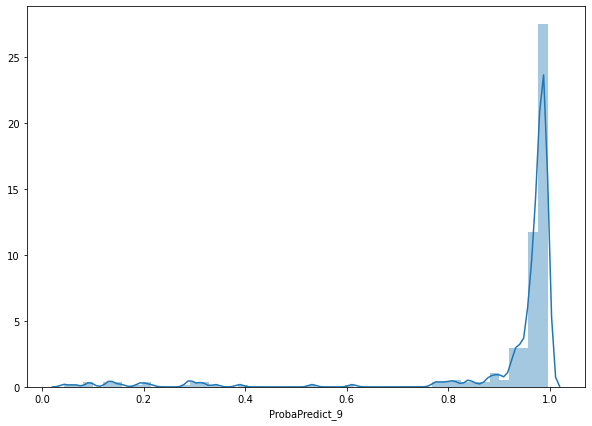

```python
# %matplotlib notebook
sns.distplot(df_val['ProbaPredict_9'], bins=50 )
plt.show()
```

```python
threshold = 0.65
```

```python
df_val['test_'] =  df_val['ProbaPredict_9'].apply(lambda x: 1 if x >= threshold else 0)
```

```python
np.array(df_val[['ProbaPredict_9', 'test_']])
```

[output not shown]

[output cut: 245 more lines]

[output not shown]

```python
met1 = confusion_matrix(df_val[final_target_bin], df_val['test_'])
met1
```

```
array([[ 13,  19],
       [  7, 261]], dtype=int64)
```

```python
# точность класса платящего
met1[1][1] / (met1[0][1] + met1[1][1] )
```

```
0.9321428571428572
```

```python
# полнота для класса платящего (процет платящих из всех платящих)
met1[1][1] / (met1[1][0] + met1[1][1] )
```

```
0.9738805970149254
```

```python
# процент отказов
df_val['test_'].isin([0]).sum(), str(df_val['test_'].isin([0]).sum()/ len(df_val) * 100 // 1) +'%'
```

```
(20, '6.0%')
```

### Тестовая выборка поссле threshold

```python
len(df_learn )
```

```
108
```

```python
x_to_predict_1 = df_learn[result_tab]
```

```python
df_learn['ProbaPredict_9'] = clf_res9.predict_proba(x_to_predict_1)[:, 1]
```

```python
print(roc_auc_score( df_learn[final_target_bin], df_learn.ProbaPredict_9 ) )
```

```
0.9381443298969072
```

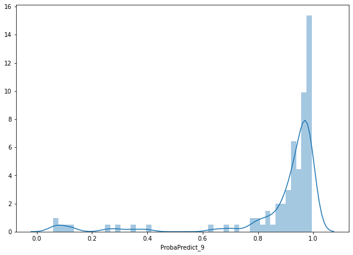

```python
sns.distplot(df_learn['ProbaPredict_9'], bins=50 )
plt.show()
```

```python
df_learn['test_'] =  df_learn['ProbaPredict_9'].apply(lambda x: 1 if x >= threshold else 0) # устанвливаем проверочный threshold проыеренный на доп выборке выше
```

```python
df_learn[final_target_bin].isin([0]).sum(), df_learn[final_target_bin].isin([1]).sum()
```

```
(11, 97)
```

```python
df_learn['test_'].isin([0]).sum(), df_learn['test_'].isin([1]).sum()
```

```
(10, 98)
```

```python
(df_learn[df_learn[final_target_bin].isin([1])][final_target_bin]==df_learn[df_learn[final_target_bin].isin([1])]['test_']).sum()
```

```
95
```

```python
(df_learn[df_learn[final_target_bin].isin([0])][final_target_bin]==df_learn[df_learn[final_target_bin].isin([0])]['test_']).sum()
```

```
8
```

```python
#https://en.wikipedia.org/wiki/Confusion_matrix
met = confusion_matrix(  df_learn[final_target_bin], df_learn['test_'])
met
```

```
array([[ 8,  3],
       [ 2, 95]], dtype=int64)
```

```python
# точность класса платящего
met[1][1] / (met[0][1] + met[1][1] )
```

```
0.9693877551020408
```

```python
# полнота для класса платящего (процет платящих из всех платящих)
met[1][1] / (met[1][0] + met[1][1] )
```

```
0.979381443298969
```

**Процент отказов**

```python
# процент отказов
df_learn['test_'].isin([0]).sum(), str(df_learn['test_'].isin([0]).sum()/ len(df_learn) * 100 // 1) +'%'
```

```
(10, '9.0%')
```

```python
df_learn.columns.tolist()
```

```
['CreditAutoID',
 'AutoID',
 'PersonID',
 'CreditID',
 'Марка, модель',
 'Бренд',
 'Модель',
 'Год выпуска',
 'Одобренная сумма',
 'Дата возврата. План',
 'Установка GPS',
 'Срок действия ПТС на дату одобрения в мес.',
 'Срок действия ПТС 1 и меннее мес.',
 'Срок действия ПТС 15 и меннее дней',
 'Срок действия ПТС 1 день и менее',
 'Наличие данных о серии и номере СТС',
 'Наличие страховки',
 'Разтаможка',
 'Наличие VIN',
 'Наличие номера кузова',
 'Цвет кузова',
 'Тип Цвета',
 'MadeInRussia',
 'BCategory',
 'DCategory',
 'Дата регистрации ПТС',
 'Срок действия ПТС на дату одобрения в мес. по послед. влад.',
 'Срок действия ПТС 1 и меннее мес. по послед. влад.',
 'Срок действия ПТС 15 и меннее дней по послед. влад.',
 'Срок действия ПТС 1 день и менее по послед. влад.',
 'Кол-во владельцев',
 'Дубликат ПТС',
 'Регион ПТС по послед. владельцу',
 'IDРегиона',
 'УкрупнениеIDРегиона',
 'is_informative',
 'Расходы на услуги связи по абонентскому номеру',
 'Расходы на услуги связи по абонентскому номеруID',
 'Размер максимального платежа)',
 'Размер максимального платежа)ID',
```

[output cut: 172 more lines]

```
 'eqf_all_Сумма остатков договоров на просрочке более 300 дней',
 'eqf_all_Полная стоимость займа (кредита) в соответствии с договором займа (кредита)',
 'eqf_all_Размер периодического платежа (аннуитет)',
 'eqf_all_Сумма договора поручительства',
 'eqf_all_Сумма банковской гарантии',
 'Доля оплаты в ОД',
 'Доля  eqf_all_Сумма открытых договоров в выдаче',
 'Доля выданной сумма от оценочной стоимости',
 'Год выдачи',
 'Месяц выдачи',
 'Кол-во дней от выдачи',
 'Группа по сумме выдачи',
 'Группа доли выдачи в стоимости',
 'ProbaPredict_9',
 'test_']
```

**Дефолт на сегодня у тестовой выборки**

```python
df_learn['Состояние займа на сегодня'].map(lambda x: 1 if x>=1 else 0).mean()
```

```
0.12962962962962962
```

**Дефолт на сегодня у тестовой выборки после скоринга**

```python
df_learn[df_learn['test_']==1]['Состояние займа на сегодня'].map(lambda x: 1 if x>=1 else 0).mean()
```

```
0.05102040816326531
```

**Займы в просрчоке на сегодня**

```python
df_learn[df_learn['Состояние займа на сегодня'] >=1 ]['Сумма выдачи'].sum(), df_learn[df_learn['Состояние займа на сегодня'] >=1 ]['Сборы всего'].sum(), df_learn[df_learn['Состояние займа на сегодня'] >=1 ]['Сборы всего'].sum() / df_learn[df_learn['Состояние займа на сегодня'] >=1 ]['Сумма выдачи'].sum()
```

```
(4956000.0, 2817015.25, 0.5684050141242938)
```

**Займы с отказом по скорингу**

```python
df_learn[df_learn['test_']==0]['Сумма выдачи'].sum(), df_learn[df_learn['test_']==0]['Сборы всего'].sum(), df_learn[df_learn['test_']==0]['Сборы всего'].sum() / df_learn[df_learn['test_']==0]['Сумма выдачи'].sum()
```

```
(3465000.0, 2328100.15, 0.6718903751803752)
```

**Процент фактически погашенных займов среди тех кому отказали**

```python
(df_learn[df_learn['test_']==0]['Сборы всего']  / df_learn[df_learn['test_']==0]['Сумма выдачи'] >=1).sum() / len(df_learn[df_learn['test_']==0])
```

```
0.3
```

```python
df_learn[df_learn['test_']==0][['Сумма выдачи', 'Одобренная сумма', 'Доля оплаты в ОД', 'Состояние займа на сегодня',
                                'Максимальный срок просрочки', 'Доля выданной сумма от оценочной стоимости',
                                'Доля выданной сумма от желаемой', 'Срок действия ПТС на дату одобрения в мес. по послед. влад.', 'Год выпуска' ]]\
                                .sort_values(by='Сумма выдачи', ascending=False)
```

|  | Сумма выдачи | Одобренная сумма | Доля оплаты в ОД | Состояние займа на сегодня | Максимальный срок просрочки | Доля выданной сумма от оценочной стоимости | Доля выданной сумма от желаемой | Срок действия ПТС на дату одобрения в мес. по послед. влад. | Год выпуска |
| --- | --- | --- | --- | --- | --- | --- | --- | --- | --- |
| 1491 | 483000.0 | 482700.0 | 0.0807 | 363 | 362 | 1.0006 | 0.9660 | 12.0 | 2008.0 |
| 1374 | 443000.0 | 670000.0 | 1.5472 | 27 | 107 | 0.6611 | 0.8860 | 11.0 | 2013.0 |
| 1544 | 413000.0 | 413300.0 | 0.0000 | 369 | 368 | 0.9992 | 0.9177 | 11.0 | 2008.0 |
| 1545 | 409000.0 | 409200.0 | 0.9290 | 354 | 353 | 0.9995 | 0.9088 | 11.0 | 2012.0 |
| 1482 | 362000.0 | 431320.0 | 0.8287 | 356 | 355 | 0.8392 | 0.9050 | 11.0 | 2004.0 |
| 1639 | 353000.0 | 353000.0 | 1.0178 | -1 | 0 | 1.0000 | 0.7844 | 11.0 | 2008.0 |
| 1337 | 350000.0 | 355000.0 | 0.8571 | 322 | 321 | 0.9859 | 10.0000 | 10.0 | 2012.0 |
| 1636 | 303000.0 | 369700.0 | 0.0028 | 375 | 374 | 0.8195 | 0.7575 | 11.0 | 2008.0 |
| 1325 | 292000.0 | 384385.0 | 0.5479 | 328 | 327 | 0.7596 | 0.9733 | 11.0 | 2004.0 |
| 1478 | 57000.0 | 59400.0 | 1.8156 | 46 | 66 | 0.9595 | 0.9500 | 12.0 | 2006.0 |

**Займы с одобрением по скорингу**

```python
df_learn[(df_learn['test_']==1) & (df_learn['Сумма выдачи']>=300000)][['Сумма выдачи', 'Одобренная сумма', 'Доля оплаты в ОД', 'Состояние займа на сегодня',
                                'Максимальный срок просрочки', 'Доля выданной сумма от оценочной стоимости',
                                'Доля выданной сумма от желаемой', 'Срок действия ПТС на дату одобрения в мес. по послед. влад.', 'Год выпуска' ]]\
                                .sort_values(by='Сумма выдачи', ascending=False)
```

|  | Сумма выдачи | Одобренная сумма | Доля оплаты в ОД | Состояние займа на сегодня | Максимальный срок просрочки | Доля выданной сумма от оценочной стоимости | Доля выданной сумма от желаемой | Срок действия ПТС на дату одобрения в мес. по послед. влад. | Год выпуска |
| --- | --- | --- | --- | --- | --- | --- | --- | --- | --- |
| 1493 | 500000.0 | 242000.0 | 1.0315 | -1 | 0 | 2.0661 | 1.0000 | 28.0 | 2009.0 |
| 1485 | 500000.0 | 532800.0 | 0.5436 | 81 | 80 | 0.9384 | 1.0000 | 8.0 | 2018.0 |
| 1356 | 500000.0 | 616300.0 | 1.1201 | -1 | 0 | 0.8112 | 1.0000 | 9.0 | 2008.0 |
| 1534 | 500000.0 | 636600.0 | 0.0000 | 386 | 385 | 0.7854 | 1.0000 | 27.0 | 2006.0 |
| 1552 | 500000.0 | 592950.0 | 1.0615 | -1 | 0 | 0.8432 | 1.0000 | 37.0 | 2008.0 |
| 1547 | 500000.0 | 1844000.0 | 1.0804 | -1 | 0 | 0.2711 | 1.0000 | 22.0 | 2011.0 |
| 1320 | 500000.0 | 551000.0 | 0.8089 | 0 | 0 | 0.9074 | 1.0000 | 0.0 | 2010.0 |
| 1574 | 480000.0 | 1866400.0 | 1.4546 | -1 | 14 | 0.2571 | 0.9600 | 11.0 | 2013.0 |
| 1576 | 453000.0 | 456050.0 | 0.6548 | 0 | 0 | 0.9933 | 0.9060 | 17.0 | 2005.0 |
| 1546 | 450000.0 | 510300.0 | 1.1771 | -1 | 0 | 0.8818 | 0.9000 | 11.0 | 2006.0 |
| 1302 | 438000.0 | 437575.0 | 0.7586 | 27 | 26 | 1.0009 | 0.9733 | 11.0 | 2004.0 |
| 1330 | 403000.0 | 472700.0 | 1.3305 | -1 | 0 | 0.8525 | 1.0075 | 10.0 | 2007.0 |
| 1475 | 400000.0 | 400800.0 | 1.1502 | -1 | 0 | 0.9980 | 0.8888 | 99.0 | 2007.0 |
| 1486 | 400000.0 | 656000.0 | 1.2362 | 0 | 0 | 0.6097 | 0.8888 | 22.0 | 2007.0 |
| 1298 | 363000.0 | 363750.0 | 0.9362 | 0 | 20 | 0.9979 | 0.9075 | 12.0 | 2004.0 |
| 1637 | 358000.0 | 358000.0 | 1.1878 | -1 | 0 | 1.0000 | 0.8950 | 82.0 | 2008.0 |
| 1638 | 353000.0 | 467500.0 | 1.1463 | -1 | 0 | 0.7550 | 1.0085 | 22.0 | 2008.0 |
| 1538 | 353000.0 | 467800.0 | 0.7012 | 0 | 9 | 0.7545 | 1.0085 | 10.0 | 2008.0 |
| 1568 | 353000.0 | 430000.0 | 1.0000 | -1 | 0 | 0.8209 | 1.0085 | 0.0 | 2007.0 |
| 1567 | 353000.0 | 454000.0 | 1.3697 | -1 | 8 | 0.7775 | 1.0085 | 10.0 | 2007.0 |
| 1319 | 350000.0 | 693600.0 | 1.1202 | -1 | 0 | 0.5046 | 1.0000 | 12.0 | 2011.0 |
| 1573 | 339000.0 | 436000.0 | 1.2264 | -1 | 0 | 0.7775 | 0.9685 | 37.0 | 2005.0 |
| 1553 | 303000.0 | 313000.0 | 1.3285 | -1 | 0 | 0.9680 | 0.8657 | 14.0 | 2003.0 |
| 1489 | 303000.0 | 309000.0 | 1.5704 | -1 | 10 | 0.9805 | 1.0100 | 12.0 | 2012.0 |
| 1259 | 302000.0 | 302000.0 | 1.0045 | -1 | 0 | 1.0000 | 0.8628 | 24.0 | 2003.0 |

```python
df_learn[df_learn['test_']==0]['Сумма выдачи'].mean(), df_learn[df_learn['test_']==1]['Сумма выдачи'].mean()
```

```
(335000.0, 195697.91666666666)
```

```python
df_learn[df_learn['test_']==0]['Сумма выдачи'].median(), df_learn[df_learn['test_']==1]['Сумма выдачи'].median()
```

```
(351500.0, 153000.0)
```

```python
df_learn[df_learn['test_']==0]['Одобренная сумма'].mean(), df_learn[df_learn['test_']==1]['Одобренная сумма'].mean()
```

```
(385115.8333333333, 305432.96875)
```

```python
df_learn[df_learn['test_']==0]['Доля выданной сумма от оценочной стоимости'].mean(), df_learn[df_learn['test_']==1]['Доля выданной сумма от оценочной стоимости'].mean()
```

```
(0.8883416666666665, 0.7154562500000003)
```

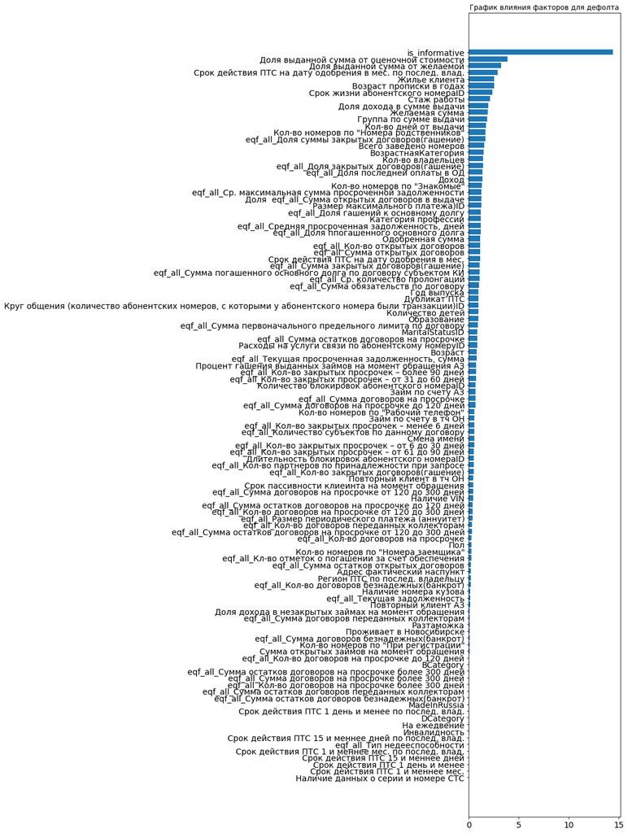

```python
# https://pyprog.pro/mpl/mpl_bar.html

fig, subplot = plt.subplots()
fig.set_size_inches(15, 20)


x = importances_clf9.reset_index().sort_values(by='clf', ascending=True)['index'].values
y = importances_clf9.reset_index().sort_values(by='clf', ascending=True)['clf'].values

subplot.set_title('График влияния факторов для дефолта')
subplot.barh(x, y)

plt.tick_params( labelsize=14)
plt.tight_layout()
plt.show()
```

```python
importances_clf9.reset_index()
```

|  | index | clf |
| --- | --- | --- |
| 0 | is_informative | 14.403423 |
| 1 | Доля выданной сумма от оценочной стоимости | 3.901148 |
| 2 | Доля выданной сумма от желаемой | 3.268436 |
| 3 | Срок действия ПТС на дату одобрения в мес. по ... | 2.916603 |
| 4 | Жилье клиента | 2.543170 |
| ... | ... | ... |
| 105 | Срок действия ПТС 1 и меннее мес. по послед. в... | 0.000416 |
| 106 | Срок действия ПТС 1 и меннее мес. | 0.000000 |
| 107 | Срок действия ПТС 15 и меннее дней | 0.000000 |
| 108 | Срок действия ПТС 1 день и менее | 0.000000 |
| 109 | Наличие данных о серии и номере СТС | 0.000000 |

110 rows × 2 columns

```python
importances_clf9.index.tolist()
```

```
['is_informative',
 'Доля выданной сумма от оценочной стоимости',
 'Доля выданной сумма от желаемой',
 'Срок действия ПТС на дату одобрения в мес. по послед. влад.',
 'Жилье клиента',
 'Возраст прописки в годах',
 'Срок жизни абонентского номераID',
 'Стаж работы',
 'Доля дохода в сумме выдачи',
 'Желаемая сумма',
 'Группа по сумме выдачи',
 'Кол-во дней от выдачи',
 'Кол-во номеров по "Номера родственников"',
 'eqf_all_Доля суммы закрытых договоров(гашение)',
 'Всего заведено номеров',
 'ВозрастнаяКатегория',
 'Кол-во владельцев',
 'eqf_all_Доля закрытых договоров(гашение)',
 'eqf_all_Доля последней оплаты в ОД',
 'Доход',
 'Кол-во номеров по "Знакомые"',
 'eqf_all_Ср. максимальная сумма просроченной задолженности',
 'Доля  eqf_all_Сумма открытых договоров в выдаче',
 'Размер максимального платежа)ID',
 'eqf_all_Доля гашений к основному долгу',
 'Категория профессии',
 'eqf_all_Средняя просроченная задолженность, дней',
 'eqf_all_Доля ппогашенного основного долга',
 'Одобренная сумма',
 'eqf_all_Кол-во открытых договоров',
 'eqf_all_Сумма открытых договоров',
 'Срок действия ПТС на дату одобрения в мес.',
 'eqf_all_Сумма закрытых договоров(гашение)',
 'eqf_all_Сумма погашенного основного долга по договору субъектом КИ',
 'eqf_all_Ср. количество пролонгаций',
 'eqf_all_Сумма обязательств по договору',
 'Год выпуска',
 'Дубликат ПТС',
 'Круг общения (количество абонентских номеров, с которыми у абонентского номера были транзакции)ID',
 'Количество детей',
```

[output cut: 55 more lines]

```
 'eqf_all_Кол-во договоров на просрочке более 300 дней',
 'eqf_all_Сумма остатков договоров переданных коллекторам',
 'eqf_all_Сумма остатков договоров безнадежных(банкрот)',
 'MadeInRussia',
 'Срок действия ПТС 1 день и менее по послед. влад.',
 'DCategory',
 'На ежедвение',
 'Инвалидность',
 'Срок действия ПТС 15 и меннее дней по послед. влад.',
 'eqf_all_Тип недееспособности',
 'Срок действия ПТС 1 и меннее мес. по послед. влад.',
 'Срок действия ПТС 1 и меннее мес.',
 'Срок действия ПТС 15 и меннее дней',
 'Срок действия ПТС 1 день и менее',
 'Наличие данных о серии и номере СТС']
```

```python
# num = 0
# factors_ = []
# for i in importances_clf9.reset_index()['index']:
#     num += importances_clf9[i]
#     if num <= 95:
#         factors_.append(i)

# print(len(factors_), len(result_tab), len(factors_) / len(result_tab))
# factors_
```

```python
# [i for i in factors_ if i in features ]
```

```python
clf_res9.save_model('D:/Ponomarev/МодлеьАвтозаймы/finel_modeCatB10112020' )
```

```python
# from_file = CatBoostClassifier()

# from_file.load_model("model")
```

```python
# df_learn.to_excel('D:/Ponomarev/МодлеьАвтозаймы/ResultScor_clf_res_def.xlsx')
```

**Расчёт лимита выдачи**

Максимальная сумма займа 300000

```python
max_limit = 300000
```

Текущая методология расчета лимитиа (оценочной стоимости)

- (-15%) поправочный к/ф от рыночной стоимости
- `* на тариф ( в ср.65% от к/ф от рыночной стоимости ) т.е. - 35%
- (-~5% стомость ремонта от стоимости по тарифу)

```python
# Расчетная Оценочная стоимость добавляем вычтенный тариф,
height_price = lambda x: x * 1.35
df_learn['Оценочная стоимость'] = df_learn['Одобренная сумма'].apply(height_price)
df_learn['Оценочная стоимость'].value_counts()
```

```
518919.75    3
278100.00    2
197437.50    2
80696.25     2
58050.00     2
            ..
743850.00    1
551340.00    1
185814.00    1
80190.00     1
45360.00     1
Name: Оценочная стоимость, Length: 102, dtype: int64
```

```python
df_learn['ProbaPredict_9']
```

```
1475    0.979599
1298    0.780135
1491    0.073165
1478    0.348400
1573    0.955338
          ...
1577    0.987840
1486    0.982227
1431    0.977425
1645    0.978261
1358    0.933477
Name: ProbaPredict_9, Length: 108, dtype: float64
```

```python
def linear_value(range_, low_threshold, fact, high_threshold=1):

    if fact > high_threshold:
        raise ValueError(f"fact is greater than high_threshold: {fact}>{high_threshold}")
    if not range_:
        return 0
    if fact > low_threshold:
        x1, x2, y1, y2 = low_threshold, high_threshold, min(range_), max(range_)
        k = (y2-y1)/(x2-x1)
        b = y1-k*x1
        y = k * fact + b
    else:
        y = min(range_)
    return y

def apply_concavity(x, r, conc):

#     assert not x < min(r), 'resolution more '

    rmin, rmax = min(r, default=0), max(r, default=0)
    assert rmin <= x <= rmax, 'resolution is out of range'
    y = ((rmax - rmin) ** conc - (rmax - x) ** conc) ** (1 / conc) + rmin
    return y

def round_value_to_list(value, list_, round_to_zero=False):
    """
    round_to_zero:
    False - no zeroing
    'soft' - soft round to zero
    'hard' - hard round to zero
    """
    if round_to_zero and value <= 0.001:
        return 0
    if round_to_zero == 'hard' and value < min(list_):
        return 0
    nearest = min(list_, key=lambda x: abs(x-value), default=0)
    return nearest


# r = [1,2,3,4, 10]


# 0 - нижняя граница, 0.1 - скорбалл текущего клиента, 1 - выпуклость (чем она больше, тем выше лимиты)
```

```python
_df_cost = pd.read_excel("D:\Ponomarev\МодлеьАвтозаймы\Оценочная стоимость корр.xlsx").set_index('CreditID')
_df_cost.head(3)
```

| CreditID | PersonID | Сумма выдачи | Марка, модель | Одобренная сумма факт | Рыночная стоимость | Рсчет | Поправочный к/ф | Уценка | Стоимость ремонта | Оценочная стоимость корр | Корр Одобрено |
| --- | --- | --- | --- | --- | --- | --- | --- | --- | --- | --- | --- |
| 3593360 | 983003 | 400000 | VOLVO XC90 | 400800 | 660000 | 660000-10%*70%-15000 | 0.1 | 0.7 | 15000 | 580500 | 406350.0 |
| 3595894 | 983753 | 363000 | PORSCHE CAYENNE | 363750 | 625000 | 625000-10%*70%-30000 | 0.1 | 0.7 | 30000 | 535500 | 374850.0 |
| 3598601 | 984553 | 483000 | LEXUS GS450H | 482700 | 790000 | 790000-10%*70%-15000 | 0.1 | 0.7 | 15000 | 697500 | 488250.0 |

```python
df_learn_cost = df_learn.merge(_df_cost[['Оценочная стоимость корр','Корр Одобрено']], how='left', left_on='CreditID', right_on='CreditID')
df_learn_cost['Оценочная стоимость корр'].head(3)
```

```
0    580500
1    535500
2    697500
Name: Оценочная стоимость корр, dtype: int64
```

```python
threshold
```

```
0.65
```

```python
def limit(df_learn_cost):
#     r = list(range(int(df_learn['Оценочная стоимость'] * 0.2 / 1000), int(df_learn['Оценочная стоимость']/1000), 10 ))
    max_limit = int(500000/1000)
    cost = df_learn_cost['Оценочная стоимость корр']

    price_min = int(cost * 0.3 / 1000)
    price_max = int(cost / 1000)

    if price_min < 50:
        r_min = 50
    else:
        r_min = price_min

#     if price_max > max_limit:
#         r_max = max_limit
#     else:
#         r_max = price_max

    r = list(range( int(r_min), int(price_max), 10 ))
    lb = threshold
    score = df_learn_cost['ProbaPredict_9']
    conc = 1
    return round_value_to_list(apply_concavity(linear_value(r, lb, score), r, conc), r)
```

```python
df_learn_cost['Доступный лимит'] = df_learn_cost.apply(limit, axis=1) * 1000
df_learn_cost[['Сумма выдачи', 'Одобренная сумма', 'Оценочная стоимость корр', 'test_', 'Доступный лимит', 'Доля оплаты в ОД', 'Кол-во дней от выдачи']]
```

|  | Сумма выдачи | Одобренная сумма | Оценочная стоимость корр | test_ | Доступный лимит | Доля оплаты в ОД | Кол-во дней от выдачи |
| --- | --- | --- | --- | --- | --- | --- | --- |
| 0 | 400000.0 | 400800.0 | 580500 | 1 | 554000 | 1.1502 | 434.0 |
| 1 | 363000.0 | 363750.0 | 535500 | 1 | 300000 | 0.9362 | 432.0 |
| 2 | 483000.0 | 482700.0 | 697500 | 0 | 209000 | 0.0807 | 431.0 |
| 3 | 57000.0 | 59400.0 | 95000 | 0 | 50000 | 1.8156 | 428.0 |
| 4 | 339000.0 | 436000.0 | 510000 | 1 | 463000 | 1.2264 | 425.0 |
| ... | ... | ... | ... | ... | ... | ... | ... |
| 103 | 100000.0 | 150000.0 | 212000 | 1 | 203000 | 1.3675 | 295.0 |
| 104 | 400000.0 | 656000.0 | 1120000 | 1 | 1076000 | 1.2362 | 294.0 |
| 105 | 73000.0 | 106400.0 | 175000 | 1 | 162000 | 0.5912 | 292.0 |
| 106 | 50000.0 | 160000.0 | 207000 | 1 | 192000 | 1.0927 | 287.0 |
| 107 | 283000.0 | 304700.0 | 418500 | 1 | 355000 | 1.0039 | 286.0 |

108 rows × 7 columns

```python
df_learn_cost[df_learn_cost['test_']==1]['Доступный лимит'].sum(), df_learn_cost[df_learn_cost['test_']==1]['Корр Одобрено'].sum()
```

```
(38499000, 31058920.0)
```

```python
df_learn_cost[df_learn_cost['test_']==0]['Доступный лимит'].sum(), df_learn_cost[df_learn_cost['test_']==0]['Корр Одобрено'].sum()
```

```
(1463000, 3353380.0)
```

```python
df_learn_cost[df_learn_cost['test_']==0][['Сумма выдачи', 'Корр Одобрено', 'Оценочная стоимость корр',
          'test_', 'Доступный лимит', 'Доля оплаты в ОД', 'Кол-во дней от выдачи']]
```

|  | Сумма выдачи | Корр Одобрено | Оценочная стоимость корр | test_ | Доступный лимит | Доля оплаты в ОД | Кол-во дней от выдачи |
| --- | --- | --- | --- | --- | --- | --- | --- |
| 2 | 483000.0 | 488250.0 | 697500 | 0 | 209000 | 0.0807 | 431.0 |
| 3 | 57000.0 | 66500.0 | 95000 | 0 | 50000 | 1.8156 | 428.0 |
| 22 | 303000.0 | 393750.0 | 562500 | 0 | 168000 | 0.0028 | 405.0 |
| 32 | 413000.0 | 425250.0 | 607500 | 0 | 182000 | 0.0000 | 399.0 |
| 36 | 353000.0 | 365400.0 | 522000 | 0 | 156000 | 1.0178 | 394.0 |
| 40 | 362000.0 | 385560.0 | 642600 | 0 | 192000 | 0.8287 | 386.0 |
| 41 | 409000.0 | 417600.0 | 522000 | 0 | 156000 | 0.9290 | 384.0 |
| 64 | 292000.0 | 402570.0 | 575100 | 0 | 172000 | 0.5479 | 358.0 |
| 68 | 350000.0 | 342000.0 | 427500 | 0 | 128000 | 0.8571 | 352.0 |
| 96 | 443000.0 | 66500.0 | 95000 | 0 | 50000 | 1.5472 | 302.0 |

```python
df_learn_cost.columns.tolist()
```

```
['CreditAutoID',
 'AutoID',
 'PersonID',
 'CreditID',
 'Марка, модель',
 'Бренд',
 'Модель',
 'Год выпуска',
 'Одобренная сумма',
 'Дата возврата. План',
 'Установка GPS',
 'Срок действия ПТС на дату одобрения в мес.',
 'Срок действия ПТС 1 и меннее мес.',
 'Срок действия ПТС 15 и меннее дней',
 'Срок действия ПТС 1 день и менее',
 'Наличие данных о серии и номере СТС',
 'Наличие страховки',
 'Разтаможка',
 'Наличие VIN',
 'Наличие номера кузова',
 'Цвет кузова',
 'Тип Цвета',
 'MadeInRussia',
 'BCategory',
 'DCategory',
 'Дата регистрации ПТС',
 'Срок действия ПТС на дату одобрения в мес. по послед. влад.',
 'Срок действия ПТС 1 и меннее мес. по послед. влад.',
 'Срок действия ПТС 15 и меннее дней по послед. влад.',
 'Срок действия ПТС 1 день и менее по послед. влад.',
 'Кол-во владельцев',
 'Дубликат ПТС',
 'Регион ПТС по послед. владельцу',
 'IDРегиона',
 'УкрупнениеIDРегиона',
 'is_informative',
 'Расходы на услуги связи по абонентскому номеру',
 'Расходы на услуги связи по абонентскому номеруID',
 'Размер максимального платежа)',
 'Размер максимального платежа)ID',
```

[output cut: 174 more lines]

```
 'eqf_all_Размер периодического платежа (аннуитет)',
 'eqf_all_Сумма договора поручительства',
 'eqf_all_Сумма банковской гарантии',
 'Доля оплаты в ОД',
 'Доля  eqf_all_Сумма открытых договоров в выдаче',
 'Доля выданной сумма от оценочной стоимости',
 'Год выдачи',
 'Месяц выдачи',
 'Кол-во дней от выдачи',
 'Группа по сумме выдачи',
 'Группа доли выдачи в стоимости',
 'ProbaPredict_9',
 'test_',
 'Оценочная стоимость',
 'Доступный лимит']
```

```python
df_learn_cost[['PersonID','CreditID', 'Сумма выдачи', 'Марка, модель', 'Корр Одобрено', 'Оценочная стоимость корр',
          'test_', 'Доступный лимит', 'Доля оплаты в ОД', 'Кол-во дней от выдачи',
          'Состояние займа на сегодня', 'Максимальный срок просрочки', 'Доля выданной сумма от оценочной стоимости',
          'Доля выданной сумма от желаемой', 'Срок действия ПТС на дату одобрения в мес. по послед. влад.',
          'Год выпуска']]\
          .to_excel('D:/Ponomarev/МодлеьАвтозаймы/Limit1.xlsx')
```

```python
Auto_EquifaxFeatures =  ['num', 'dateofreport', 'responsecode', 'responsestring', 'lastname', 'firstname',
 'middlename', 'birthday', 'birthplace', 'doctype', 'docno',
 'docdate', 'docplace', 'private_inn', 'pfno', 'fullname', 'resident',
 'regcountry', 'commercial_inn', 'egrn', 'pboul_no', 'addr_reg_total',
 'addr_fact_total', 'phone', 'incapacity_type', 'incapacity_date', 'ci_cred_no',
 'ci_cred_date', 'ci_cred_type', 'ci_op_cred_debt', 'ci_ta_cred_debt', 'cred_id',
 'cred_first_load', 'cred_owner', 'cred_partner_type', 'cred_guarantee_volume',
 'cred_person_num', 'cred_ratio', 'cred_sum', 'cred_sum_first', 'cred_currency',
 'cred_special_status', 'cred_no', 'cred_date', 'cred_enddate', 'cred_sum_payout',
 'cred_date_payout', 'op_cred_sum_paid', 'ta_cred_sum_paid', 'cred_date_percent',
 'cred_sum_debt', 'cred_sum_limit', 'cred_facility', 'delay5', 'delay30', 'delay60',
 'delay90', 'delay_more', 'cred_sum_overdue', 'cred_day_overdue', 'cred_max_overdue',
 'cred_prolong', 'grace_type', 'grace_date', 'grace_enddate', 'grace_reason', 'grace_endreason',
 'cred_collateral', 'cred_update', 'cred_type', 'cred_active', 'cred_active_date', 'cred_sum_type',
 'cred_full_cost', 'cred_annuity', 'collateral_count', 'assessment_sum', 'assessment_cur',
 'collateral_list', 'guarantee_count', 'guarantee_sum', 'guarantee_cur', 'guarantee_list',
 'bank_guarant_count', 'bank_guarant_sum', 'bank_guarant_cur', 'bank_guarant_list',
 'collection_unpaid_count', 'collection_unpaid_sum', 'collection_unpaid_sum_current',
 'collection_paid_count', 'collection_paid_sum', 'collection_cur', 'collection_list',
 'cred_court_count', 'cred_court_list', 'other_court_count', 'other_court_list', 'cred_official_count',
 'cred_official_list', 'other_official_count', 'other_official_list', 'bankruptcy_count',
 'bankruptcy_list', 'interest_hour', 'interest_day', 'interest_week', 'interest_month',
 'interest_quarter', 'interest_year', 'own_interest_hour', 'own_interest_day', 'own_interest_week',
 'own_interest_month', 'own_interest_quarter', 'own_interest_year', 'other_interest_hour_list',
 'other_interest_day_list', 'other_interest_week_list', 'other_interest_month_list',
 'other_interest_quarter_list', 'other_interest_year_list', 'scor_card_id_list',
 'score_list', 'payment_discipline', 'cred_attr_id_list', 'cred_attr_list', 'payments',
 'payments_month', 'attr_id_list', 'attr_list'
]
```

```python
 updateEquifax =[
"inqrep.value((cred_id)[1], bigint) as [ID договора]",
"inqrep.value((cred_first_load)[1], datetime) as [Дата начала выгрузок в БКИ]",
"inqrep.value((cred_owner)[1], int) as [Займ взят в ОН]",
"inqrep.value((cred_partner_type)[1], int)  as [Тип источника информации]",
"inqrep.value((cred_person_num)[1], int) as [Кол-во СКИ]",
"inqrep.value((cred_ratio)[1], int) as [Отношение субъекта к данному договору]",
"inqrep.value((cred_sum)[1], money) as [Сумма обязательств (лимит)]",
"inqrep.value((cred_date)[1], datetime) as [Дата выдачи/открытия]",
"inqrep.value((cred_enddate)[1], datetime) as [Дата погашения по договору]",
"inqrep.value((cred_sum_payout)[1], money) as [Сумма последнего платежа]",
"inqrep.value((cred_date_payout)[1], datetime) as [Дата последнего платежа]",
"inqrep.value((cred_sum_debt)[1], money) as [Текущая просроченная задолженность]",
"inqrep.value((cred_sum_limit)[1], money) as [Текущий неиспользованный лимит]",
"inqrep.value((delay5)[1], int) as [Кол-во закрытых просрочек менее 6 дней]",
"inqrep.value((delay30)[1], int) as [Кол-во закрытых просрочек от 6 до 30 дней]",
"inqrep.value((delay60)[1], int) as [Кол-во закрытых просрочек от 31 до 60 дней]",
"inqrep.value((delay90)[1], int) as [Кол-во закрытых просрочек от 61 до 90 дней]",
"inqrep.value((delay_more)[1], int) as [Кол-во закрытых просрочек более 90 дней]",
"inqrep.value((cred_sum_overdue)[1], float) as [Текущая задолженность]",
"inqrep.value((cred_day_overdue)[1], int) as [Текущая просроченная задолженность, дней]",
"inqrep.value((cred_max_overdue)[1], float) as [Макс сумма просроченной задолженности]",
"inqrep.value((cred_prolong)[1], int) as [Кол-во пролонгаций]",
"inqrep.value((cred_enddate_fact)[1], datetime) as [Дата фактич. исполнения обязательств]",
"inqrep.value((cred_collateral)[1], int) as [Погашение за счет обеспечения]",
"inqrep.value((cred_update)[1], datetime) as [Дата актуальности информации]",
"inqrep.value((cred_type)[1], int) as [Тип кредита]",
"inqrep.value((cred_active)[1], int) as [Состояние договора]",
"inqrep.value((cred_active_date)[1], datetime) as [Дата перехода договора в данное состояние]",
"inqrep.value((cred_sum_type)[1], int) as [Тип отображения задолженности]as [Тип отображения задолженности]",
"IIF(ResponseCode<>1, null, sc.score) as score,",
"sc.Scor_name,",
"iif((ResponseXML.value((/bki_response/response/responsestring)[1], nvarchar(max))=Клиент найден и у него есть кредитная история and ResponseXML.exist(/bki_response/response/title_part)=0) or (ResponseCode<>1 or ResponseCode is null), 0, 1) as ContainsKI ",
",ResponseXML.value((/bki_response/response/add_part/interest_hour)[1], int) as [eq_interest_hour]",
",ResponseXML.value((/bki_response/response/add_part/interest_day)[1], int) as [eq_interest_day]",
",ResponseXML.value((/bki_response/response/add_part/interest_week)[1], int) as [eq_interest_week]",
",ResponseXML.value((/bki_response/response/add_part/interest_month)[1], int) as [eq_interest_month]",
",ResponseXML.value((/bki_response/response/add_part/interest_quarter)[1], int) as [eq_interest_quarter]",
",ResponseXML.value((/bki_response/response/add_part/interest_year)[1], int) as [eq_interest_year]",
",ResponseXML.value((/bki_response/response/add_part/own_interest_hour)[1], int) as [eq_interest_partner_hour]",
",ResponseXML.value((/bki_response/response/add_part/own_interest_day)[1], int) as [eq_interest_partner_day]",
",ResponseXML.value((/bki_response/response/add_part/own_interest_week)[1], int) as [eq_interest_partner_week]",
",ResponseXML.value((/bki_response/response/add_part/own_interest_month)[1], int) as [eq_interest_partner_month]",
",ResponseXML.value((/bki_response/response/add_part/own_interest_quarter)[1], int) as [eq_interest_partner_quarter]",
",ResponseXML.value((/bki_response/response/add_part/own_interest_year)[1], int) as [eq_interest_partner_year]",
"ch.ResponseXML.nodes(/bki_response/response/add_part/scorings/scoring) AS XmlResponse(inqrep)",
"ch.ResponseXML.nodes(/bki_response/response/add_part/attrs/package/section/period/attr) AS XmlResponse(inqrep)"
 ]
```

```python
import re
```

```python
p = f'inqrep.value((delay30)[1], int) as [Кол-во закрытых просрочек от 6 до 30 дней]'
p.strip().replace(' ', '_')
```

```
'inqrep.value((delay30)[1],_int)_as_[Кол-во_закрытых_просрочек_от_6_до_30_дней]'
```

```python
n = 0
no_el = []
for i in updateEquifax:
    for  x in Auto_EquifaxFeatures:
        p = f'{x}\w*'

        if len(re.findall(p, i)):
            if re.findall(p, i)[0]==x:
                name = re.findall('as\w+.\w+.\w+.\w+]$', i.strip().replace(' ', '_'))
                if len(str(name)) > 2:
                    name_r = name[0].replace('as_', 'as ')
                else:
                    name_r = 'as []'
                n += 1
                print(n, '//', x, '//', name_r)

print(len(Auto_EquifaxFeatures), len(updateEquifax) )
```

```
1 // cred_id // as [ID_договора]
2 // cred_first_load // as [Дата_начала_выгрузок_в_БКИ]
3 // cred_owner // as [Займ_взят_в_ОН]
4 // cred_partner_type // as [Тип_источника_информации]
5 // num // as [Кол-во_СКИ]
6 // cred_person_num // as [Кол-во_СКИ]
7 // cred_ratio // as [Отношение_субъекта_к_данному_договору]
8 // cred_sum // as []
9 // cred_date // as [Дата_выдачи/открытия]
10 // cred_enddate // as [Дата_погашения_по_договору]
11 // cred_sum_payout // as [Сумма_последнего_платежа]
12 // cred_date_payout // as [Дата_последнего_платежа]
13 // cred_sum_debt // as [Текущая_просроченная_задолженность]
14 // cred_sum_limit // as [Текущий_неиспользованный_лимит]
15 // delay5 // as [Кол-во_закрытых_просрочек_менее_6_дней]
```

[output cut: 34 more lines]

## **Модель Pycaret**

```python
df_train9.sort_values('Дата открытия по договору')
Debt = df_train9['Месяц выдачи'].value_counts().reset_index()
Debt.columns = ['Месяц выдачи', 'Кол-во выдач']
Debt.sort_values('Месяц выдачи', ascending=False)
```

|  | Месяц выдачи | Кол-во выдач |
| --- | --- | --- |
| 37 | 2020-02 | 5 |
| 20 | 2019-08 | 28 |
| 25 | 2019-07 | 25 |
| 27 | 2019-06 | 19 |
| 29 | 2019-05 | 19 |
| 30 | 2019-04 | 18 |
| 22 | 2019-03 | 27 |
| 23 | 2019-02 | 27 |
| 33 | 2019-01 | 14 |
| 18 | 2018-12 | 30 |
| 28 | 2018-11 | 19 |
| 31 | 2018-10 | 17 |
| 36 | 2018-09 | 12 |
| 34 | 2018-08 | 14 |
| 35 | 2018-07 | 13 |
| 17 | 2018-06 | 30 |
| 0 | 2018-05 | 50 |
| 13 | 2018-04 | 35 |
| 2 | 2018-03 | 48 |
| 16 | 2018-02 | 31 |
| 19 | 2018-01 | 30 |
| 9 | 2017-12 | 40 |
| 7 | 2017-11 | 41 |
| 8 | 2017-10 | 41 |
| 4 | 2017-09 | 44 |
| 11 | 2017-08 | 37 |
| 14 | 2017-07 | 34 |
| 3 | 2017-06 | 45 |
| 5 | 2017-05 | 41 |
| 6 | 2017-04 | 41 |
| 1 | 2017-03 | 50 |
| 15 | 2017-02 | 31 |
| 12 | 2017-01 | 35 |
| 10 | 2016-12 | 37 |
| 24 | 2016-11 | 26 |
| 21 | 2016-10 | 27 |
| 26 | 2016-09 | 25 |
| 32 | 2016-08 | 16 |

```python
pd.unique(df_train9['ВозрастнаяКатегория']).tolist()
```

```python
cat_agg = [
    'РанняяВзрослость',
    'Студенты',
    'СредняяВзрослость',
    'ЗрелыйВозраст',
    'ПредПенсионныйВозраст',
    'ПожилойВозраст'
]
```

```python
targ = 'Платящий на 240 дне'
```

```python
numeric = features
res_f = categorical + numeric + [targ]
res_f
```

**py_caret**

```python
df_train_r = df_train9[res_f]
```

```python
setdf = setup(df_train_r, numeric_features=numeric, target=targ, high_cardinality_features=categorical,
              normalize_method='robust', train_size=0.90)
#categorical_features=categorical, , categorical_imputation=categorical multicollinearity_threshold=0.6,
```

```python
compare_models(blacklist=['xgboost', 'lightgbm'], fold=3)
```

```python
cr = create_model('catboost', fold =3)
```

```python
tune_catboost = tune_model(cr, optimize='AUC', fold=3) #'catboost', fold=3,
```

```python
tune_catboost.get_all_params()
```

```python
importances_pycaret = pd.Series(tune_catboost.feature_importances_, index=result_tab).rename('clf')  # влияние предикатов
importances_pycaret = importances_pycaret.sort_values(ascending=False)
print(importances_pycaret[:10])
```

```python
# interpret_model(tune_catboost)
```

```python
save_model(tune_catboost, 'mode_pycaret_05112020')
```

```python
pred1 = predict_model(tune_catboost, data=df_learn)
```

```python
pred1
```

```python
roc_auc_score(pred1[targ], pred1['Score'])
```

```python
sns.distplot( pred1.Score, bins=50 )
plt.show()
```

```python
pred1['Score'].describe()
```

```python
cvant_50_ = np.percentile(pred1['Score'], 50 )
cvant_25_ = np.percentile(pred1['Score'], 25 )

def scor_rez2(pred1):
    if pred1['Желаемая сумма'] < 200000:

        if pred1['Score'] > cvant_50_:
            return  1
        else:
            return  0
    elif pred1['Желаемая сумма'] >= 200000:

        if pred1['Score'] > cvant_25_:
            return  1
        else:
            return  0
```

```python
pred1['test'] =  pred1['Score'].apply(lambda x: 1 if x > .80 else 0) # .57 трэш холд граница
```

```python
met2 = confusion_matrix(pred1[final_target_bin],  pred1['test'])
met2
```

```python
# точность класса
met2[1][1] / (met2[0][1] + met2[1][1] )
```

```python
# полнота для класса дефолта (процет плохих из всех плохих)
met2[1][1] / (met2[1][0] + met2[1][1] )
```

```python
finel_model = finalize_model(tune_catboost)
```

```python
save_model(finel_model, 'D:/Ponomarev/МодлеьАвтозаймы/finel_mode11112020')
```

```python
# pred1.to_excel('D:/Ponomarev/МодлеьАвтозаймы/ResultScor2Def2.xlsx')
```

# Раздел: Результаты скоринга

**Отобранные факторы:**

```python
[ [i, el] for i, el in enumerate(result_tab)]
```

**топ 10 влияющих факторов:**

```python
[ print(i+1, el) for i, el in enumerate(importances_clf9.reset_index().sort_values(by='clf', ascending=False)['index'][:10] )][0]
```

[output not shown]

**Целевая:**

`Целевая переменная - платящий на 240 дне ( отсуствие просрочки на 240 день после выдачи )

**Выборка для обучения**

- ~1000 контрактов

**Тестируемая выборка**

**Результаты теста:** полученная вероятнотсь делится по группе суммы займа до 200 тыс.руб и более 200 тыс.руб

```python
df_learn['Оценочная стоимость'] = df['Одобренная сумма'] * 1.15
```

```python
df_learn['Максимальный лимит'] = 500000
```

```python
df_learn['ProbaPredict_def'].max()
```

**Расчет коэффициента корректировки суммы лимита**

```python
# cvant_50_ = np.percentile(df_learn['ProbaPredict_def'], 50 )
cvant_q_ = np.percentile(df_learn['ProbaPredict_def'], 10 )

def per_lim(df_learn):
    if df_learn['Желаемая сумма'] < 200000:
        res = ( df_learn['ProbaPredict_def'] / cvant_50_ ) - 1
        if res < 0:
            return abs(res) + 1
        else:
            return 1 - res

    elif df_learn['Желаемая сумма'] >= 200000:
        res = ( df_learn['ProbaPredict_def'] / cvant_q_ ) - 1
        if res < 0:
            return abs(res) + 1
        else:
            return 1 - res
```

```python
df_learn['NormaScor'] = df_learn.apply(per_lim, axis=1)
df_learn['NormaScor']
```

```python
df_learn['Верхняя граница для расчета лимита'] = df_learn['Оценочная стоимость'] * 0.80
# df_learn['База для расчета лимита']=
```

```python
def limit(df_learn):
    ns = df_learn['NormaScor']
    max_cst = df_learn['Верхняя граница для расчета лимита']
    max_lim = df_learn['Максимальный лимит']
    ws_first = df_learn['Желаемая сумма']

    if ws_first >= max_cst:
        ws = max_cst  * 0.90
    else:
        ws = ws_first


#     if ns < 1:
#         per = 1 - ns
#         lim = per * ws
#     else:
    lim = ns * ws

    if lim < max_cst:
        if lim > max_lim:
            return max_lim
        else:
            return lim
    else:
        if max_cst >  max_lim:
            return max_lim
        else:
            return max_cst
```

```python
df_learn['limit'] = df_learn.apply(limit, axis=1).apply(math.ceil)
df_learn['limit']
```

```python
df_learn.columns.tolist()
```

```python
vbr = [ 'PersonID', 'CreditID', 'Дефолт', 'ProbaPredict_def',  'test_def', 'NormaScor', 'limit', 'Оценочная стоимость',
          'Верхняя граница для расчета лимита',  'Желаемая сумма', 'Одобренная сумма', 'Сумма выдачи' ]
df_learn[vbr]
```

**Отклонения лимита по скорингу от суммы выдачи**

- Сумма выдачи увеличилась на 790 тыс.руб., сумма определенная дефолтной увеличилась на 1,4 тыс.руб.

```python
df_learn.groupby('test_def')['limit'].sum() - df_learn.groupby('Дефолт')['Сумма выдачи'].sum()
```

По контрактам которые фактически дефолтные сумма лимита меньше суммы выдачи на 678 тыс. руб.

```python
df_learn[df_learn['Дефолт'] == 1]['limit'].sum() - df_learn[df_learn['Дефолт'] == 1]['Сумма выдачи'].sum()
```

```python
def_scor_fact = df_learn[df_learn['Дефолт'] == 1]['limit'].sum() / df_learn['limit'].sum() * 100
def_scor_fact
```

```python
def_scor = df_learn[df_learn['test_def'] == 1]['limit'].sum() / df_learn['limit'].sum() * 100
def_scor
```

```python
df_learn[df_learn['Дефолт'] == 1]['Сумма выдачи'].sum() / df_learn['Сумма выдачи'].sum() * 100
```

```python
df_learn[vbr].to_excel("D:\Ponomarev\МодлеьАвтозаймы\ResultScorAuto.xlsx")
```